# Airbnb_NYC_2019_Final-Copy2

## **Feature: review_scores_cleanliness** (Discrete)

```python
preliminaries(listings_explore, 'review_scores_cleanliness')
```

```
Dtype:  float64
Missing Values:  261
```

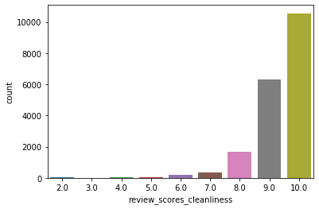

```python
sns.countplot(listings_explore.review_scores_cleanliness.dropna())
plt.show()
```

Mode at 10, some at 9 and 8, skews left.

```python
disc_attribs.append('review_scores_cleanliness')
```

## **Feature: review_scores_checkin** (Discrete)

```python
preliminaries(listings_explore, 'review_scores_checkin')
```

```
Dtype:  float64
Missing Values:  263
```

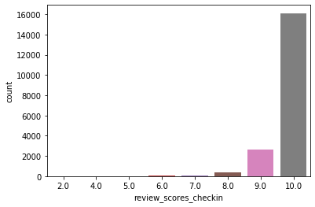

```python
sns.countplot(listings_explore.review_scores_checkin.dropna())
plt.show()
```

Mode at 10, some at 9, skews left.

```python
disc_attribs.append('review_scores_checkin')
```

## **Feature: review_scores_communication** (Discrete)

```python
preliminaries(listings_explore, 'review_scores_communication')
```

```
Dtype:  float64
Missing Values:  261
```

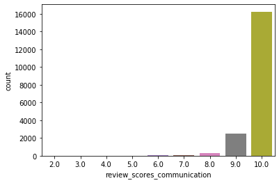

```python
sns.countplot(listings_explore.review_scores_communication.dropna())
plt.show()
```

Mode at 10, some at 9, skews left.

```python
disc_attribs.append('review_scores_communication')
```

Ready to impute.

## **Feature: review_scores_location** (Discrete)

```python
preliminaries(listings_explore, 'review_scores_location')
```

```
Dtype:  float64
Missing Values:  263
```

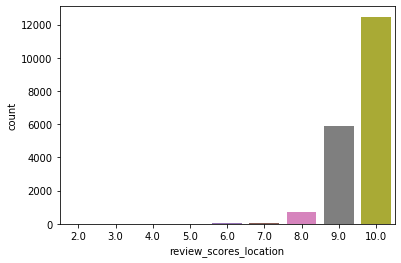

```python
sns.countplot(listings_explore.review_scores_location.dropna())
plt.show()
```

Mode at 10, half at 9, some at 8, skews left.

```python
disc_attribs.append('review_scores_location')
```

## **Feature: review_scores_value** (Discrete)

```python
preliminaries(listings_explore, 'review_scores_value')
```

```
Dtype:  float64
Missing Values:  263
```

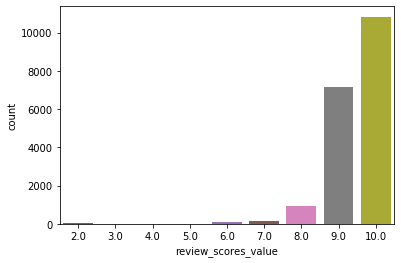

```python
sns.countplot(listings_explore.review_scores_value.dropna())
plt.show()
```

Mode at 10, close to 9, a few at 8, skews left.

```python
disc_attribs.append('review_scores_value')
```

Ready to impute.

**Features: calculated_host_listings_count, calculated_host_listings_count_entire_homes, calculated_host_listings_count_private_rooms, calculated_host_listings_count_shared_rooms**

These features have been dropped as they do not seem to directly contribute much more information to the potential renter as to whether they will rent or not. I understand that there may be a correlation between having more or less listings and, for instance, reviews or price, but we have chosen to leave these features out for reasons of streamlining this process, and I feel the other features cover much of the needed to determine the price.

```python
listings_explore.drop(columns=['calculated_host_listings_count',
                               'calculated_host_listings_count_entire_homes',
                               'calculated_host_listings_count_private_rooms',
                               'calculated_host_listings_count_shared_rooms'], inplace=True)
dropped_cols.extend(['calculated_host_listings_count',
                     'calculated_host_listings_count_entire_homes',
                     'calculated_host_listings_count_private_rooms',
                     'calculated_host_listings_count_shared_rooms'])
```

## **Feature: reviews_per_month**

```python
preliminaries(listings_explore, 'reviews_per_month')
```

```
Dtype:  float64
Missing Values:  0
```

```python
sum_stats(listings_explore.reviews_per_month)
```

```
nobs: 19506
median: 1.37
mode: [1.]
mean: 1.9028078539936428
std: 1.7616027593254382
minmax: (0.02, 28.0)
25% 0.58
50% 1.37
75% 2.77
skewness: 1.969132469374286
```

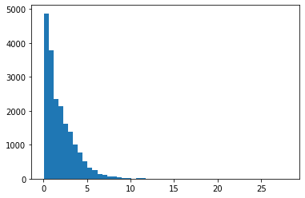

```python
plt.hist(listings_explore.reviews_per_month, bins=50)
plt.show()
```

Mode at 0, many up to 4. Skews right up to 28.

```python
num_attribs.append('reviews_per_month')
```

Ready to impute.

# Categorical Features

```python
# Function to convert true/false values to binary
def convert_tf(df, column):
    '''
    Converts t/f values in a Series to 0/1.
    '''
    df[column] = df[column].map({'t': 1, 'f': 0}, na_action='ignore')
    return df[column]
```

## **Feature: host_is_superhost**

```python
preliminaries(listings_explore, 'host_is_superhost', values=True)
```

```
Dtype:  object
Missing Values:  4
f    13983
t     5519
Name: host_is_superhost, dtype: int64
```

```python
# Convert t/f to 1/0
listings_explore['host_is_superhost'] = convert_tf(listings_explore, 'host_is_superhost')
```

```python
preliminaries(listings_explore, 'host_is_superhost', values=True)
```

```
Dtype:  float64
Missing Values:  4
0.0    13983
1.0     5519
Name: host_is_superhost, dtype: int64
```

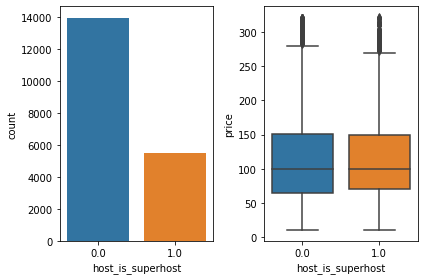

```python
fig, ax = plt.subplots(1, 2)
sns.countplot(listings_explore.host_is_superhost, ax=ax[0])
sns.catplot('host_is_superhost', 'price', data=listings_explore, kind='box', ax=ax[1])
fig.tight_layout()
plt.close()
plt.show()
```

```python
percentage_of(listings_explore.host_is_superhost, 1.0)
```

```
0.28
```

28% of hosts are superhosts.

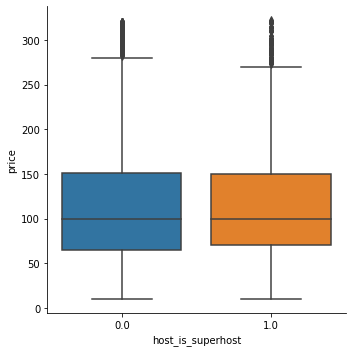

```python
sns.catplot('host_is_superhost', 'price', data=listings_explore, kind='box')
plt.show()
```

Interestingly, price does not look to be affected by whether a host is a superhost or not. If this is true, then the superhost badge is more a marketing tool for Airbnb to synthetically reward loyal hosts than it is a tool to help hosts generate more revenue.

```python
cat_attribs.append('host_is_superhost')
```

Clean.

## **Feature: host_has_profile_pic**

```python
preliminaries(listings_explore, 'host_has_profile_pic', values=True)
```

```
Dtype:  object
Missing Values:  4
t    19466
f       36
Name: host_has_profile_pic, dtype: int64
```

Virtually all listings have a profile picture, so we will remove this feature from the data.

```python
listings_explore.drop(columns='host_has_profile_pic', inplace=True)
dropped_cols.append('host_has_profile_pic')
```

Clean.

## **Feature: host_identity_verified** (For analysis only)

This column is only for analysis purposes and will be removed from the model, as the potential guest cannot see whether a host is verified.

```python
preliminaries(listings_explore, 'host_identity_verified', values=True)
```

```
Dtype:  object
Missing Values:  4
f    9841
t    9661
Name: host_identity_verified, dtype: int64
```

```python
# Convert t/f to 1/0
listings_explore['host_identity_verified'] = convert_tf(listings_explore, 'host_identity_verified')
```

```python
preliminaries(listings_explore, 'host_identity_verified', values=True)
```

```
Dtype:  float64
Missing Values:  4
0.0    9841
1.0    9661
Name: host_identity_verified, dtype: int64
```

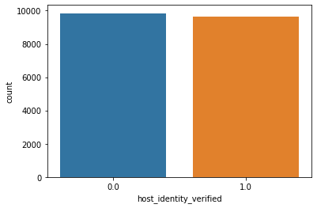

```python
sns.countplot(listings_explore.host_identity_verified)
plt.show()
```

About half of hosts are verified.

```python
#cat_attribs.append('host_identity_verified')
drop_later.append('host_identity_verified')
```

## **Feature: neighbourhood_cleansed**

```python
preliminaries(listings_explore, 'neighbourhood_cleansed')
```

```
Dtype:  object
Missing Values:  0
```

A list of value counts is the best way to view this data.

```python
cat_attribs.append('neighbourhood_cleansed')
```

## **Feature: neighbourhood_group_cleansed**

```python
preliminaries(listings_explore, 'neighbourhood_group_cleansed', values=True)
```

```
Dtype:  object
Missing Values:  0
Brooklyn         8614
Manhattan        7341
Queens           2773
Bronx             560
Staten Island     218
Name: neighbourhood_group_cleansed, dtype: int64
```

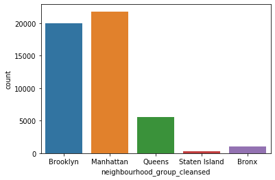

```python
sns.countplot(listings.neighbourhood_group_cleansed)
plt.show()
```

```python
percentage_of(listings_explore.neighbourhood_group_cleansed, pd.unique(listings_explore.neighbourhood_group_cleansed))
```

```
Brooklyn         0.44
Manhattan        0.38
Bronx            0.03
Queens           0.14
Staten Island    0.01
Name: neighbourhood_group_cleansed, dtype: float64
```

Brooklyn (44%) and Manhattan (38%) have by far the most listings, followed by Queens (14%), with Bronx (3%) and Staten Island (1%) quite low.

```python
cat_attribs.append('neighbourhood_group_cleansed')
```

Clean.

**Feature: zipcode**

```python
preliminaries(listings_explore, 'zipcode')
```

```
Dtype:  object
Missing Values:  216
```

```python
# Convert zipcodes to float
#listings_explore['zipcode'] = listings_train['zipcode']
#listings_explore['zipcode'] = listings_explore['zipcode'].str.replace('-', '', regex=False)
#listings_explore['zipcode'] = listings_explore['zipcode'].str.replace('NY ', '', regex=False)
#listings_explore['zipcode'] = listings_explore['zipcode'].str.replace('\n', '', regex=False)
#listings_explore['zipcode'] = listings_explore['zipcode'].str[:5].astype('float')
```

Because we have longitude and latitude, which is a more accurate measure of location, along with neighbourhood_cleansed, we will drop the zipcode feature.

```python
listings_explore.drop(columns='zipcode', inplace=True)
dropped_cols.append('zipcode')
```

## **Feature: property_type**

```python
preliminaries(listings_explore, 'property_type')
```

```
Dtype:  object
Missing Values:  0
```

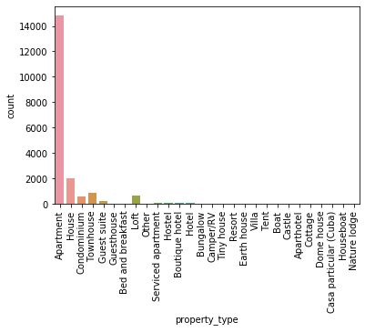

```python
fig = sns.countplot(listings_explore.property_type)
fig.set_xticklabels(labels=pd.unique(listings_explore.property_type), rotation=90)
plt.show()
```

Because we are isolating more standard Airbnbs, we will only keep the following values from the data:

```python
# Filter specific property types
listings_explore = listings_explore[
                       (listings_explore.property_type == 'Apartment') |
                       (listings_explore.property_type == 'House') |
                       (listings_explore.property_type == 'Condominium') |
                       (listings_explore.property_type == 'Townhouse') |
                       (listings_explore.property_type == 'Guest suite') |
                       (listings_explore.property_type == 'Guesthouse') |
                       (listings_explore.property_type == 'Loft') |
                       (listings_explore.property_type == 'Serviced apartment') |
                       (listings_explore.property_type == 'Tiny house') |
                       (listings_explore.property_type == 'Earth house') |
                       (listings_explore.property_type == 'Villa') |
                       (listings_explore.property_type == 'Castle') |
                       (listings_explore.property_type == 'Cottage') |
                       (listings_explore.property_type == 'Dome house')
                    ]
```

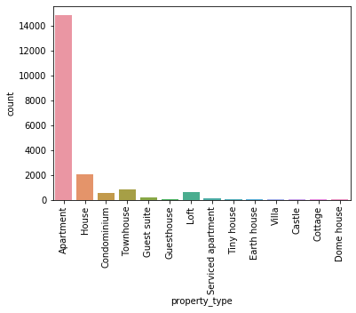

```python
fig = sns.countplot(listings_explore.property_type)
fig.set_xticklabels(labels=pd.unique(listings_explore.property_type), rotation=90)
plt.show()
```

```python
percentage_of(listings_explore.property_type, pd.unique(listings_explore.property_type))
```

```
Apartment             0.77
House                 0.11
Condominium           0.03
Townhouse             0.04
Guest suite           0.01
Guesthouse            0.00
Loft                  0.03
Serviced apartment    0.00
Tiny house            0.00
Earth house           0.00
Villa                 0.00
Castle                0.00
Cottage               0.00
Dome house            0.00
Name: property_type, dtype: float64
```

77% of listings are apartments, 11% are houses, with the remaining 10% in condominiums, townhomes, lofts, and only a few of the others.

```python
cat_attribs.append('property_type')
```

Clean.

## **Feature: room_type**

```python
preliminaries(listings_explore, 'room_type', values=True)
```

```
Dtype:  object
Missing Values:  0
Private room       9419
Entire home/apt    9361
Shared room         462
Name: room_type, dtype: int64
```

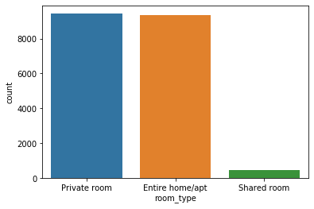

```python
sns.countplot(listings_explore.room_type)
plt.show()
```

```python
percentage_of(listings_explore.room_type, pd.unique(listings_explore.room_type))
```

```
Private room       0.49
Entire home/apt    0.49
Shared room        0.02
Name: room_type, dtype: float64
```

About 50/50 private room / entire home with only a few shared room.

```python
cat_attribs.append('room_type')
```

**Feature: is_location_exact**

```python
preliminaries(listings_explore, 'is_location_exact', values=True)
```

```
Dtype:  object
Missing Values:  0
t    15435
f     3807
Name: is_location_exact, dtype: int64
```

We're not clear what this feature measures, as we already have multiple features with location data, so we will delete this feature.

```python
listings_explore.drop(columns='is_location_exact', inplace=True)
dropped_cols.append('is_location_exact')
```

## **Feature: bed_type**

```python
preliminaries(listings_explore, 'bed_type', values=True)
```

```
Dtype:  object
Missing Values:  0
Real Bed         18933
Futon              118
Pull-out Sofa      113
Airbed              51
Couch               27
Name: bed_type, dtype: int64
```

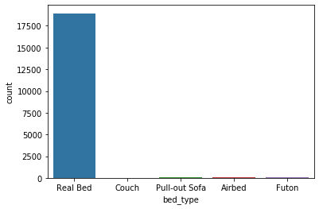

```python
sns.countplot(listings_explore.bed_type)
plt.show()
```

```python
percentage_of(listings_explore.bed_type, pd.unique(listings_explore.bed_type))
```

```
Real Bed         0.98
Couch            0.00
Pull-out Sofa    0.01
Airbed           0.00
Futon            0.01
Name: bed_type, dtype: float64
```

Virtually all real bed, with only a few of the others. Although nearly all values are one type, a real bed versus the other options is important to the quality of the listing, so we will keep this feature.

```python
cat_attribs.append('bed_type')
```

## **Feature: amenities**

The amenities feature originally consists of string lists of each amenity of the listing. We split this into binary columns for each amenity in order to accurately measure each amenity each listing has.

```python
# Example of amenity string list
listings_explore.amenities[0]
```

```
'{TV,"Cable TV",Internet,Wifi,"Wheelchair accessible",Kitchen,"Free parking on premises",Elevator,"Free street parking","Buzzer/wireless intercom",Heating,"Suitable for events",Washer,Dryer,"Smoke detector","Carbon monoxide detector","First aid kit","Safety card","Fire extinguisher",Essentials,Shamp…
```

```python
# Remove empty values ({})
listings_explore = listings_explore[listings_explore.amenities != '{}']
```

```python
# Remove brackets and quotes, split by ','
listings_explore['amenities'] = listings_explore.amenities.astype('str').str.replace('{', '', regex=False)
listings_explore['amenities'] = listings_explore.amenities.str.replace('}', '', regex=False)
listings_explore['amenities'] = listings_explore.amenities.str.replace('"', '', regex=False)
listings_explore['amenities'] = listings_explore.amenities.str.split(',')
```

```python
# An example listing's list of amenities
listings_explore['amenities'].iloc[1]
```

```
['TV',
 'Internet',
 'Wifi',
 'Air conditioning',
 'Kitchen',
 'Heating',
 'Family/kid friendly',
 'Washer',
 'Dryer',
 'Smoke detector',
 'Carbon monoxide detector',
 'Essentials',
 'Hangers',
 'Hair dryer',
 'Iron',
 'Laptop friendly workspace',
 'Hot water',
 'Other']
```

```python
# Create columns for each amenity using MultiLabelBinarizer
from sklearn.preprocessing import MultiLabelBinarizer

mlb = MultiLabelBinarizer()
amenities_df = pd.DataFrame(mlb.fit_transform(listings_explore.amenities))
classes = mlb.classes_ # amenity names
amenities_df.columns = classes # add amenity names as columns
```

```python
# Test view a row of amenities
amenities_df.head(1)
```

|  | toilet | 24-hour check-in | Accessible-height bed | Accessible-height toilet | Air conditioning | Air purifier | BBQ grill | Baby bath | Baby monitor | Babysitter recommendations | Bathtub | Bathtub with bath chair | Beach essentials | Beachfront | Bed linens | Breakfast | Building staff | Buzzer/wireless intercom | Cable TV | Carbon monoxide detector | Cat(s) | Ceiling hoist | Changing table | Children’s books and toys | Children’s dinnerware | Cleaning before checkout | Coffee maker | Cooking basics | Crib | … |
| --- | --- | --- | --- | --- | --- | --- | --- | --- | --- | --- | --- | --- | --- | --- | --- | --- | --- | --- | --- | --- | --- | --- | --- | --- | --- | --- | --- | --- | --- | --- |
| 0 | 1 | 0 | 1 | 0 | 1 | 0 | 0 | 0 | 0 | 0 | 0 | 0 | 1 | 0 | 1 | 0 | 0 | 0 | 0 | 1 | 0 | 0 | 0 | 1 | 0 | 0 | 0 | 1 | 0 | … |

```python
# Save indices
indices = np.array(listings_explore.index)
```

```python
# Merge new amenities columns with original dataframe
listings_explore = pd.concat([listings_explore.reset_index(drop=True), amenities_df.reset_index(drop=True)], axis=1)
```

```python
# Reapply original indices
listings_explore = listings_explore.set_index(indices)
```

```python
# Drop 'amenities' column
listings_explore.drop(columns='amenities', inplace=True)
```

```python
# Test view DataFrame with amenities added
listings_explore.head(1)
```

|  | host_since | host_is_superhost | host_listings_count | host_identity_verified | neighbourhood_cleansed | neighbourhood_group_cleansed | latitude | longitude | property_type | room_type | accommodates | bathrooms | bedrooms | beds | bed_type | price | cleaning_fee | guests_included | extra_people | minimum_nights | maximum_nights | calendar_updated | has_availability | availability_30 | availability_60 | availability_90 | availability_365 | number_of_reviews | number_of_reviews_ltm | … |
| --- | --- | --- | --- | --- | --- | --- | --- | --- | --- | --- | --- | --- | --- | --- | --- | --- | --- | --- | --- | --- | --- | --- | --- | --- | --- | --- | --- | --- | --- | --- |
| 37753 | 2.0 | 0.0 | 1.0 | 0.0 | Bushwick | Brooklyn | 40.70229 | -73.92223 | Apartment | Private room | 2 | 1.0 | 1.0 | 1.0 | Real Bed | 85.0 | 25.0 | 1 | 20.0 | 1 | 60 | 2 months ago | t | 6 | 20 | 50 | 325 | 38 | 38 | … |

```python
# List of columns to drop from new amenities columns
dropped_amenities = []
dropped_amenities.extend([" toilet","Accessible-height bed","Accessible-height toilet","Air purifier","BBQ grill","Baby bath","Bathtub",
"Baby monitor","Babysitter recommendations","Bathtub with bath chair","Beach essentials","Beachfront","Bed linens","Breakfast",
"Building staff","Buzzer/wireless intercom","Cable TV","Carbon monoxide detector",'Cat(s)',"Ceiling hoist","Changing table",
"Children’s books and toys","Children’s dinnerware","Cleaning before checkout","Disabled parking spot",'Dog(s)',"EV charger",
"Electric profiling bed","Ethernet connection",'Extra pillows and blankets',"Extra space around bed","Extra space around shower and toilet","Fire extinguisher",
"Fireplace guards","Firm mattress","First aid kit","Fixed grab bars for shower","Fixed grab bars for toilet","Flat path to guest entrance","Full kitchen",
"Game console","Ground floor access","High chair","Hot water kettle",'Indoor fireplace',"Internet","Keypad","Kitchenette",
'Lake access','Lock on bedroom door','Lockbox','Long term stays allowed','Luggage dropoff allowed',"Mobile hoist","No stairs or steps to enter",
"Other",'Other pet(s)',"Outlet covers",'Oven',"Pack ’n Play/travel crib","Pets live on this property","Pocket wifi","Pool with pool hoist",'Private bathroom',
"Private living room","Roll-in shower","Room-darkening shades","Safety card","Shower chair","Single level home","Ski-in/Ski-out",
"Smart lock","Smoke detector","Stair gates","Suitable for events","Table corner guards","Washer / Dryer","Well-lit path to entrance",
"Wheelchair accessible","Wide clearance to shower","Wide doorway to guest bathroom","Wide entrance","Wide entrance for guests",
"Wide entryway","Wide hallways","Window guards","translation missing: en.hosting_amenity_49","translation missing: en.hosting_amenity_50"])
# Drop unused amenities
listings_explore.drop(columns=dropped_amenities, inplace=True)
```

```python
# Create list of amenities columns
all_cols = list(listings_explore.columns)
amen_index = all_cols.index('24-hour check-in') # beginning of amenities columns
amen_attribs = all_cols[amen_index:]
```

```python
# Plot amenities columns
#for col in amen_attribs:
#    preliminaries(listings_explore, col)
#    fig, (ax1, ax2) = plt.subplots(1, 2)
#    sns.countplot(listings_explore[col], ax=ax1)
#    sns.catplot(col, 'price', data=listings_explore, kind='box', ax=ax2)
#    fig.tight_layout()
#    plt.close()
#    plt.show()
```

**Feature: calendar_updated**

```python
listings_explore.calendar_updated.value_counts()[:5]
```

```
today           2575
2 weeks ago     2108
a week ago      1491
3 weeks ago     1332
2 months ago    1317
Name: calendar_updated, dtype: int64
```

This feature doesn't seem to directly affect the price of a listing. A calendar can be updated or not, but the price is still the listed price. We will drop this feature.

However, this could be useful for analysis on prices for listings that update their prices frequently vs. listings that haven't updated in a while.

```python
listings_explore.drop(columns='calendar_updated', inplace=True)
dropped_cols.append('calendar_updated')
```

**Feature: has_availability**

```python
preliminaries(listings_explore, 'has_availability', values=True)
```

```
Dtype:  object
Missing Values:  0
t    19232
Name: has_availability, dtype: int64
```

This feature is dropped because all values are the same.

```python
listings_explore.drop(columns='has_availability', inplace=True)
dropped_cols.append('has_availability')
```

## **Feature: instant_bookable**

```python
preliminaries(listings_explore, 'instant_bookable', values=True)
```

```
Dtype:  object
Missing Values:  0
f    10763
t     8469
Name: instant_bookable, dtype: int64
```

```python
# Convert t/f to 1/0
listings_explore['instant_bookable'] = convert_tf(listings_explore, 'instant_bookable')
```

```python
preliminaries(listings_explore, 'instant_bookable', values=True)
```

```
Dtype:  int64
Missing Values:  0
0    10763
1     8469
Name: instant_bookable, dtype: int64
```

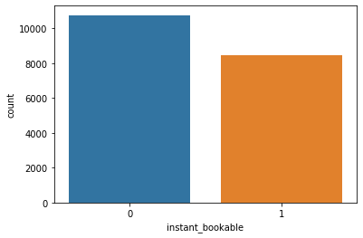

```python
sns.countplot(listings_explore.instant_bookable)
plt.show()
```

```python
percentage_of(listings_explore.instant_bookable, [0,1])
```

```
0    0.56
1    0.44
Name: instant_bookable, dtype: float64
```

instant_bookable and non-instant are similar, but not instant bookable has about 12% more instances.

```python
cat_attribs.append('instant_bookable')
```

Clean.

## **Feature: cancellation_policy**

```python
preliminaries(listings_explore, 'cancellation_policy')
```

```
Dtype:  object
Missing Values:  0
```

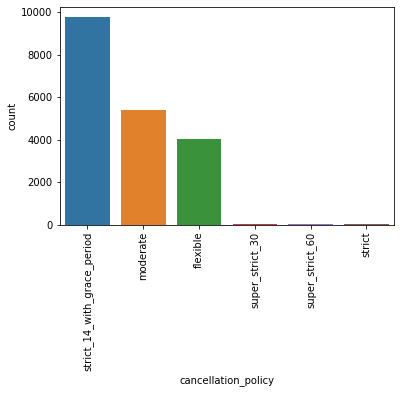

```python
fig = sns.countplot(listings_explore.cancellation_policy)
fig.set_xticklabels(labels=listings_explore.cancellation_policy.unique(), rotation=90)
plt.show()
```

```python
percentage_of(listings_explore.cancellation_policy, pd.unique(listings_explore.cancellation_policy))
```

```
strict_14_with_grace_period    0.51
moderate                       0.28
flexible                       0.21
super_strict_30                0.00
super_strict_60                0.00
strict                         0.00
Name: cancellation_policy, dtype: float64
```

```python
cat_attribs.append('cancellation_policy')
```

Clean.

**Feature: require_guest_profile_picture**

```python
preliminaries(listings_explore, 'require_guest_profile_picture', values=True)
```

```
Dtype:  object
Missing Values:  0
f    18697
t      535
Name: require_guest_profile_picture, dtype: int64
```

```python
# Convert t/f to 1/0
listings_explore['require_guest_profile_picture'] = convert_tf(listings_explore, 'require_guest_profile_picture')
```

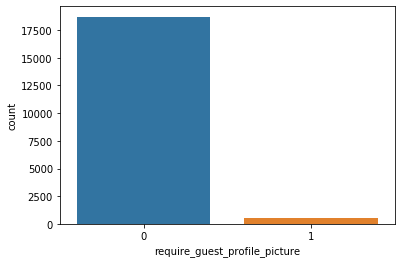

```python
sns.countplot(listings_explore.require_guest_profile_picture)
plt.show()
```

Virtually no listings require guest profile picture.

This feature is quite imbalanced and intuitively does not factor into price very much for a potential guest (as adding a profile picture is rather quick and easy with smartphones today), so we will remove this feature.

```python
listings_explore.drop(columns='require_guest_profile_picture', inplace=True)
dropped_cols.append('require_guest_profile_picture')
```

Clean.

#### **Feature: require_guest_phone_verification**

```python
preliminaries(listings_explore, 'require_guest_phone_verification', values=True)
```

```
Dtype:  object
Missing Values:  0
f    18614
t      618
Name: require_guest_phone_verification, dtype: int64
```

```python
# Convert t/f to 1/0
listings_explore['require_guest_phone_verification'] = convert_tf(listings_explore, 'require_guest_phone_verification')
```

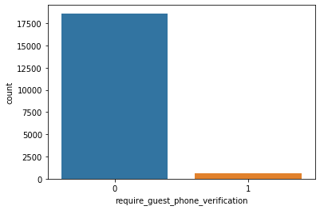

```python
sns.countplot(listings_explore.require_guest_phone_verification)
plt.show()
```

This feature is quite imbalanced and intuitively does not factor into price very much for a potential guest (as phone verification is rather easy with smartphones today), so we will remove this feature.

```python
listings_explore.drop(columns='require_guest_phone_verification', inplace=True)
dropped_cols.append('require_guest_phone_verification')
```

# Feature Correlation

Now that we have finished our first round of feature cleaning and analysis, we will move on to analyzing feature correlations.

Here, we will analyze Pearson and Spearman (linear and non-linear) feature correlations in order to remove features with multicollinearity, and identify features highly correlated with our label feature 'price'.

```python
# Send 'price' column to end of dataframe for correlation matrix readability
all_cols = listings_explore.columns.tolist()
price_ind = all_cols.index('price')
new_cols = all_cols[0:15] + all_cols[16:] + [all_cols[15]]
new_cols
listings_explore = listings_explore[new_cols]
```

### Pearson Linear Correlations

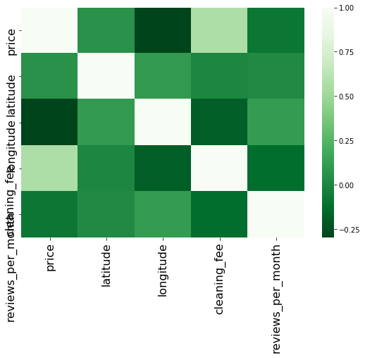

```python
# Pearson Correlation Matrix
pearson_cols = num_attribs.copy()
fig, ax = plt.subplots(figsize=(9,6))
sns.heatmap(listings_explore[pearson_cols].corr(method='pearson'), cmap='Greens_r', ax=ax)
ax.tick_params(labelsize=16)
```

Our numerical variables are not highly correlated to each other. Cleaning fee has the highest correlation to price.

We will now create a Spearman correlation matrix in order to measure non-linear correlations between our ordinal and categorical features.

### Spearman Non-Linear Correlations

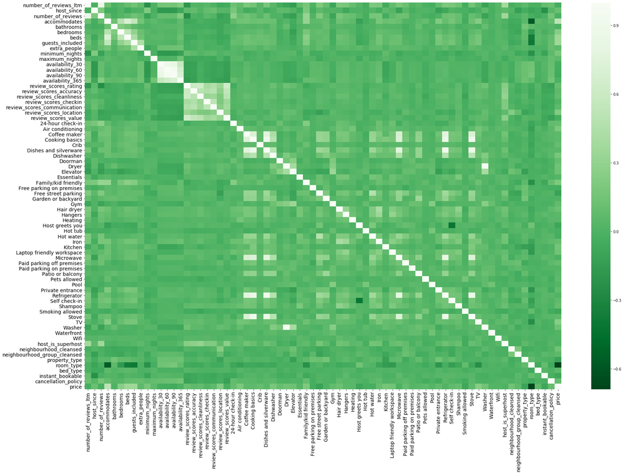

```python
# Spearman Correlation Matrix
# Create spearman dataframe
from sklearn.preprocessing import OrdinalEncoder
from sklearn.impute import SimpleImputer
spearman_df = listings_explore.copy(deep=True)
spearman_df.dropna(axis=0,inplace=True)
spearman_df[cat_attribs] = OrdinalEncoder().fit_transform(spearman_df[cat_attribs])
# Create spearman columns
spearman_cols = []
spearman_cols.extend(disc_attribs)
spearman_cols.extend(amen_attribs)
spearman_cols.extend(cat_attribs)
spearman_cols.append('price')
# Create heatmap
fig, ax = plt.subplots(figsize=(30,20))
sns.heatmap(spearman_df[spearman_cols].corr(method='spearman'), cmap='Greens_r', ax=ax)
ax.tick_params(labelsize=14)
```

Based on feature correlations, we will remove features with high multicollinearity.

```python
# Drop highly correlated features
corr_drop = ['number_of_reviews_ltm', # keep number_of_reviews (higher corr with price)
             'availability_60', 'availability_90', # keep availability_30,
             'review_scores_accuracy', 'review_scores_cleanliness', 'review_scores_checkin', 'review_scores_value', # keep rating and location
             'Dishes and silverware', 'Coffee maker', 'Refrigerator', 'Microwave', 'Stove', # keep cooking_basics
             'Dryer', # keep washer
            ]
```

```python
# DataFrame of our columns by attribute type
col_df = pd.DataFrame({'Numerical': pd.Series(num_attribs),
              'Discrete:': pd.Series(disc_attribs),
              'Categorical': pd.Series(cat_attribs),
              'Amenities': pd.Series(amen_attribs)}).fillna('')
# Dataframe of features highly correlated with price
corr_df = pd.DataFrame({'numerical': pd.Series(['longitude', 'cleaning_fee', 'reviews_per_month']),
                        'discrete': pd.Series(['host_since', 'host_listings_count', 'accommodates', 'bedrooms', 'beds', 'guests_included',
                                     'minimum_nights', 'review_scores_location']),
                        'categorical': pd.Series(['instant_bookable', 'Free parking on premises', 'Free street parking',
                                        'Host greets you', 'Hot water', 'Smoking allowed'])}).fillna('')
```

```python
# List of features highly correlated with price
highly_correlated = ['host_since', # discrete
                     'host_listings_count', # discrete
                     'longitude', # numerical
                     'accommodates', # discrete
                     'bedrooms', # discrete
                     'beds', # discrete
                     'cleaning_fee', # numerical
                     'guests_included', # discrete
                     'minimum_nights', # discrete
                     'review_scores_location', # discrete
                     'instant_bookable', # categorical
                     'reviews_per_month', # numerical
                     'Free parking on premises', # categorical
                     'Free street parking', # # categorical
                     'Host greets you', # categorical
                     'Hot water', # categorical
                     'Smoking allowed', # categorical
                     'TV', # categorical
                    ]
```

# Missing Value Imputation (for exploration of data)

This missing value imputation using Pandas is for the multi-variate analysis below, but the true missing value imputations are performed later in our Scikit-Learn Pipeline and ColumnTransformer (with the same mean/mode strategy).

```python
# Impute missing values
listings_explore.fillna(listings_explore[num_attribs].mean(), inplace=True) # mean for numerical
listings_explore.fillna(listings_explore[disc_attribs].mode().iloc[0], inplace=True) # mode
listings_explore.fillna(listings_explore[cat_attribs].mode().iloc[0], inplace=True) # mode
listings_explore.fillna(listings_explore[amen_attribs].mode().iloc[0], inplace=True) # mode
```

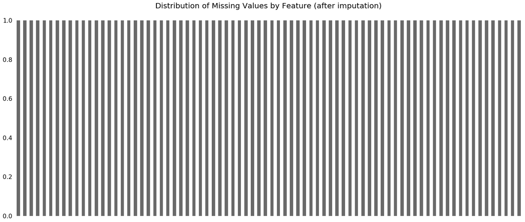

```python
# Confirm missing values imputed
missingno.bar(listings_explore)
plt.title('Distribution of Missing Values by Feature (after imputation)', fontsize=20)
plt.show()
```

# Statistical Analysis of Numerical Features

```python
# Function to plot pearsonr and p-value for regplots
from scipy.stats import pearsonr
def corrfunc(x, y, **kws):
    (r, p) = pearsonr(x, y)
    ax = plt.gca()
    ax.annotate("r = {:.2f} ".format(r),
                xy=(.1, .9), xycoords=ax.transAxes)
    ax.annotate("p = {:.3f}".format(p),
                xy=(.4, .9), xycoords=ax.transAxes)
```

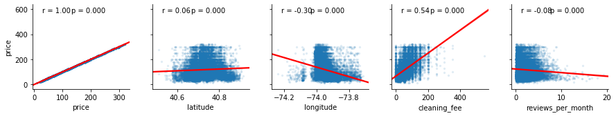

```python
# Regplot numerical features
fig = sns.pairplot(x_vars = num_attribs, y_vars='price', data=listings_explore, kind='reg',
             plot_kws={'line_kws':{'color':'red'}, 'scatter_kws': {'alpha': 0.1, 's': 5}})
fig.map(corrfunc)
plt.show()
```

```python
# Create dictionary of value counts for listings_explore for chisquare goodness of fit tests
listings_dict={}
for col in listings_explore.columns:
    listings_dict[col] = listings_explore[col].value_counts()
```

```python
# chi-square neighbourhood_cleansed
chi, p = scipy.stats.chisquare(listings_dict['neighbourhood_cleansed'])
print(chi, p)
```

```
111251.18406821963 0.0
```

```python
# chi-square neighbourhood_group_cleansed
chi, p = scipy.stats.chisquare(listings_dict['neighbourhood_group_cleansed'])
print(chi, p)
```

```
15215.532237936772 0.0
```

```python
# chi-square property_type
chi, p = scipy.stats.chisquare(listings_dict['property_type'])
print(chi, p)
```

```
144618.14871048252 0.0
```

```python
# chi-square room_type
chi, p = scipy.stats.chisquare(listings_dict['room_type'])
print(chi, p)
```

```
8282.945819467554 0.0
```

```python
# chi-square bed_type
chi, p = scipy.stats.chisquare(listings_dict['bed_type'])
print(chi, p)
```

```
73880.40744592347 0.0
```

# Multi-Variate Analysis

For our multi-variate analysis, we will think about what questions we are looking to answer with this data. The focus will be on business intelligence that will help Airbnb to gain insights into its market and drive further efficiency and revenue. Specifically, our data revolves around our hosts and their property information, so we will center our questions and strategy around our hosts.

1. Which hosts generate the most revenue? Our hosts who have been renting with Airbnb the longest, who have the most frequent bookings, who have the highest listings counts, and charge the highest price for their listings.
1. Which locations generate the most revenue?
1. Which types of places do guests rent the most? Based on reviews and frequency of stay.

Target the customers that are the most loyal. Most important hosts are hosts with more expensive places. Your average $ is gonna be the most hosts frequency-wise. How loyal are they? How many listings do they have? Segment the most expensive buildings - target them with advertising so they keep remaining loyal. Also prefer superhost/longer hosting because it means more people are gonna buy from this place. And how often their places are booked is important.

ie subscribe your good hosts to airbnb magazine.

Ideas for the future: Monitor when your hosts slow down or stop listing their listings, and blast them with marketing to get them back into hosting. Reports of subleases for longer-term stays. Where is tourism growing? Most guests are tourists.

## Host Analysis

### Which hosts have been renting with Airbnb the longest?

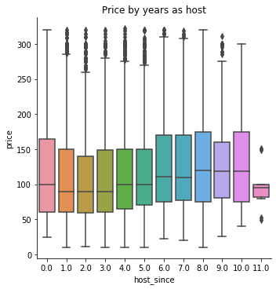

```python
sns.catplot(x='host_since', y='price', data=listings_explore, kind='box', showfliers=True)
plt.title('Price by years as host')
plt.show()
```

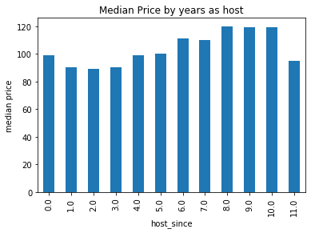

```python
listings_explore.groupby('host_since').median().price.plot(kind='bar')
plt.ylabel('median price')
plt.title('Median Price by years as host')
plt.show()
```

### Which hosts have the most frequent bookings?

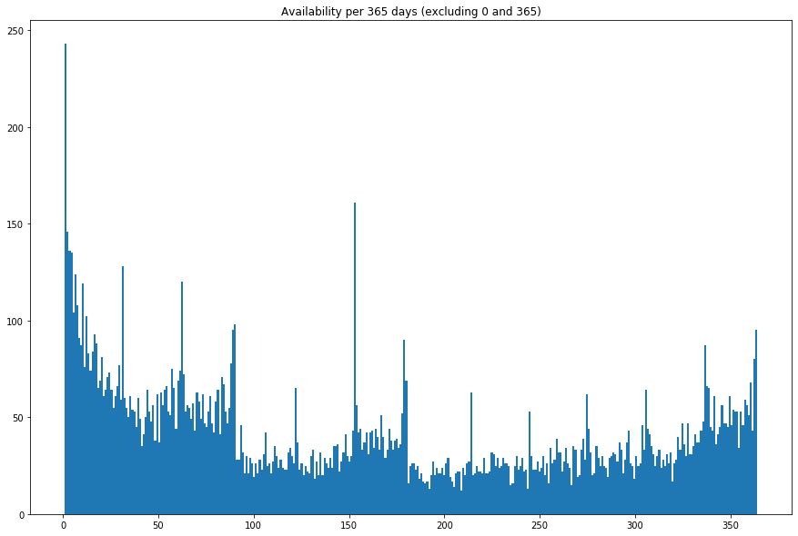

```python
plt.figure(figsize=(15,10))
plt.hist(listings_explore[(listings_explore.availability_365 > 0) & (listings_explore.availability_365 < 365)].availability_365, bins=364)
plt.title('Availability per 365 days (excluding 0 and 365)')
plt.show()
```

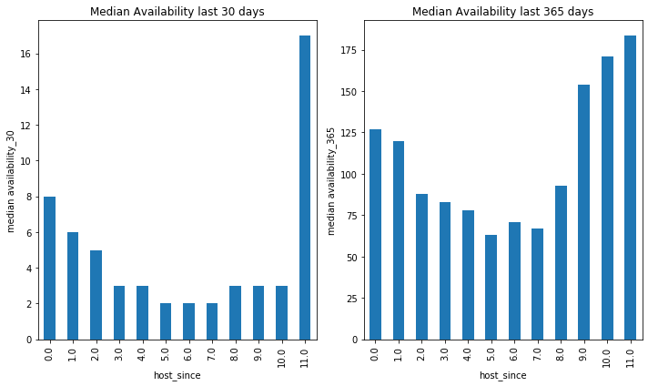

```python
fig, ax = plt.subplots(1,2,figsize=(10,6))
listings_explore.groupby('host_since').median().availability_30.plot(kind='bar', ax=ax[0])
ax[0].set_ylabel('median availability_30')
ax[0].set_title('Median Availability last 30 days')
listings_explore.groupby('host_since').median().availability_365.plot(kind='bar', ax=ax[1])
ax[1].set_ylabel('median availability_365')
ax[1].set_title('Median Availability last 365 days')
fig.tight_layout()
plt.show()
```

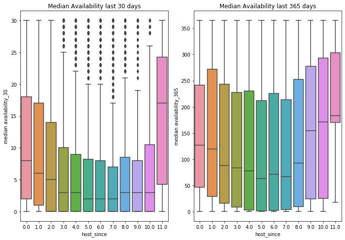

```python
fig, ax = plt.subplots(1,2,figsize=(10,7))
sns.boxplot(x='host_since', y='availability_30', data=listings_explore, ax=ax[0])
ax[0].set_ylabel('median availability_30')
ax[0].set_title('Median Availability last 30 days')
sns.boxplot(x='host_since', y='availability_365', data=listings_explore, ax=ax[1])
ax[1].set_ylabel('median availability_365')
ax[1].set_title('Median Availability last 365 days')
fig.tight_layout()
plt.show()
```

[figure not shown]

```python
fig, ax = plt.subplots(1,2,figsize=(15,7))
sns.boxplot(x='host_since', y='price', data=listings_explore,
            hue='host_is_superhost', showfliers=False, ax=ax[0])
ax[0].set_ylabel('availability_30')
ax[0].set_title('Median Availability last 30 days')
sns.boxplot(x='host_since', y='availability_365', data=listings_explore,
            hue='host_is_superhost', showfliers=False, ax=ax[1])
ax[1].set_ylabel('availability_365')
ax[1].set_title('Median Availability last 365 days')
fig.tight_layout()
plt.show()
```

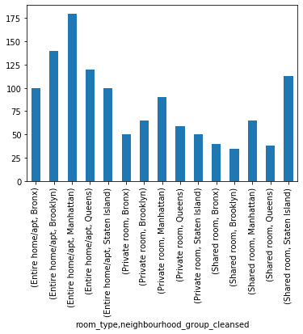

```python
listings_explore.groupby(['room_type', 'neighbourhood_group_cleansed']).median().price.plot(kind='bar')
plt.show()
```

### Which room types generate the most revenue?

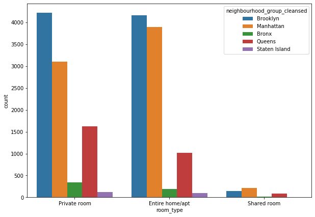

```python
plt.figure(figsize=(10,7))
sns.countplot(listings_explore.room_type, hue=listings_explore.neighbourhood_group_cleansed)
plt.show()
```

Private rooms and entire homes are by far the most common room types, at about equal frequencies. Shared rooms have very low counts in comparison.

Brooklyn has a higher ratio of private rooms, while Manhattan has a higher ratio of entire homes/apartments. This would be one reason that Manhattan's median prices are higher than Brooklyn's, along with property values in general being higher in Manhattan. Queens has more private rooms than entire homes/apartments.

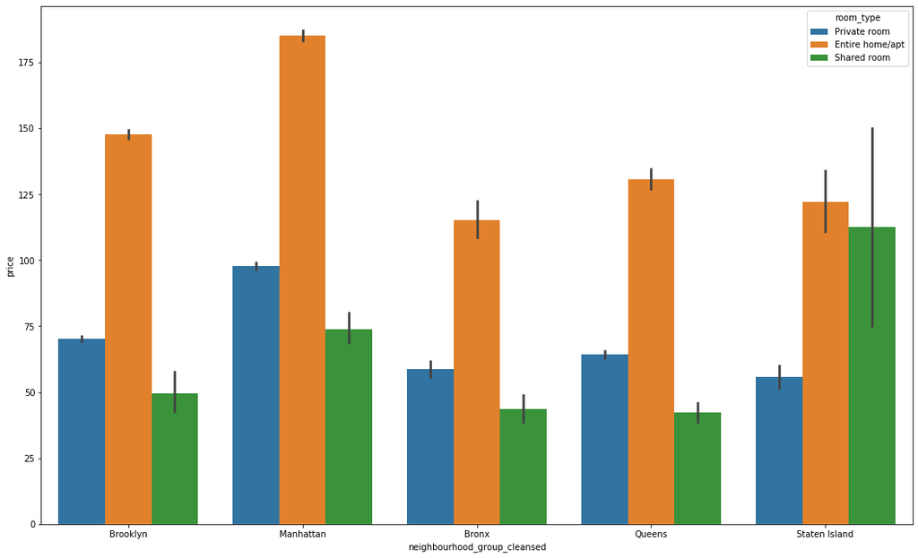

```python
plt.figure(figsize=(18,11))
sns.barplot(x='neighbourhood_group_cleansed', y='price', hue='room_type', data=listings_explore)
plt.show()
```

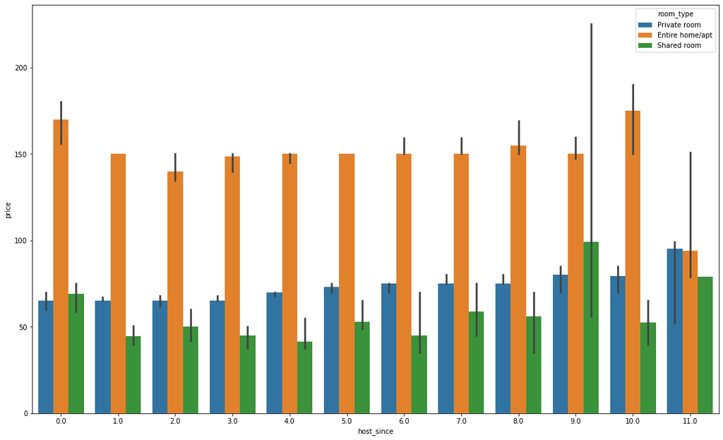

```python
plt.figure(figsize=(18,11))
sns.barplot(x='host_since', y='price', hue='room_type', data=listings_explore[listings_explore.host_listings_count < 10], ci=95, estimator=median)#, ci=95)#, showfliers=False)
plt.title('')
plt.show()
```

### Which hosts have the most listings?

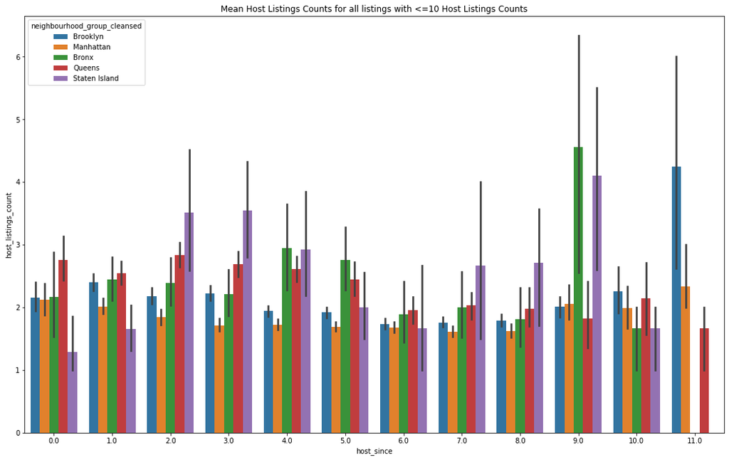

```python
plt.figure(figsize=(18,11))
sns.barplot(x='host_since', y='host_listings_count', hue='neighbourhood_group_cleansed', data=listings_explore[listings_explore.host_listings_count<=10], ci=95)#, estimator=mean)#, ci=95)#, showfliers=False)
plt.title('Mean Host Listings Counts for all listings with <=10 Host Listings Counts')
plt.show()
```

## Location Analysis

#### Locations by Borough

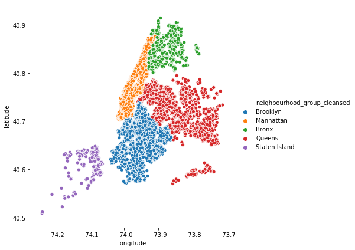

```python
sns.relplot(x='longitude', y='latitude', hue='neighbourhood_group_cleansed',
            data=listings_explore, height=6, aspect=1)
plt.figsize = (10,7)
plt.show()
```

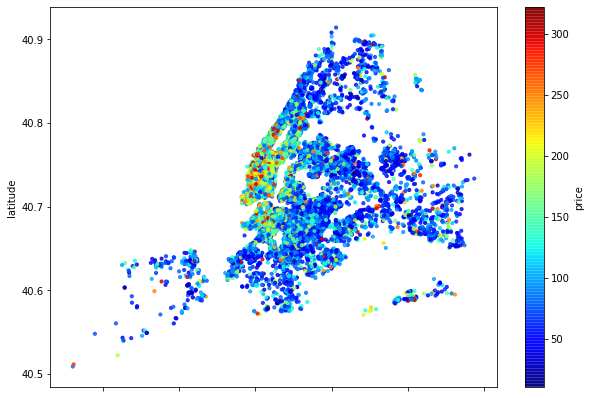

```python
fig = listings_explore.plot(kind='scatter', x="longitude", y="latitude", alpha=0.8,
                            figsize=(10,7), c='price', cmap=plt.get_cmap("jet"),
                            colorbar=True, s=10)
plt.show()
```

Manhattan and northern Brooklyn have significantly higher prices than other boroughs (the lowest Manhattan prices are in the far Upper West Side nearing the Bronx). Prices also seem to rise near bodies of water.

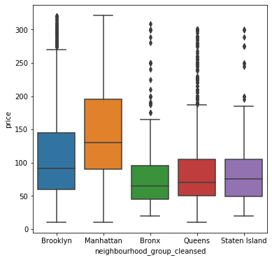

```python
plt.figure(figsize=(6,6))
sns.boxplot(x='neighbourhood_group_cleansed', y='price',
            data=listings_explore)
plt.show()
```

```python
# Create dataframe of neighborhoods and their median prices (for >=5 listings)

neighbourhoods_medians = []
neighbourhoods_names = []

for neighbourhood in listings_explore.neighbourhood_cleansed.unique():
    #print('{} Prices:\n'.format(neighbourhood))
    if len(listings_explore[listings_explore.neighbourhood_cleansed == neighbourhood]) >= 5:
        neighbourhoods_medians.append(listings_explore[listings_explore.neighbourhood_cleansed == neighbourhood].price.median())
        neighbourhoods_names.append(str(neighbourhood))

nbh_medians = pd.DataFrame({'neighbourhood': neighbourhoods_names, 'median_price': neighbourhoods_medians})
nbh_medians.sort_values(by=['median_price'], ascending=False, inplace=True)
```

The boxplots confirm that Manhattan has the highest prices on average, followed by Brooklyn (its upper range likely coming from northern Brooklyn).

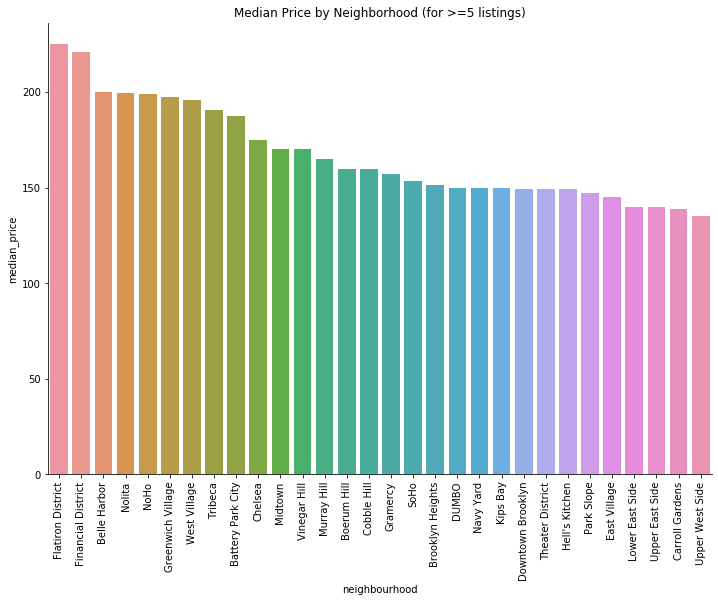

```python
# Top 10 and bottom 10 median prices (for neighborhoods with >=5 total listings)
#sns.set(font_scale=1.5, )
fig = sns.catplot(x='neighbourhood', y='median_price', data=nbh_medians.iloc[pd.np.r_[0:30]],#, -19:-1, -1]],
                  kind='bar', height=7, aspect=1.5)
fig.set_xticklabels(rotation=90)
plt.title('Median Price by Neighborhood (for >=5 listings)')
plt.show()
```

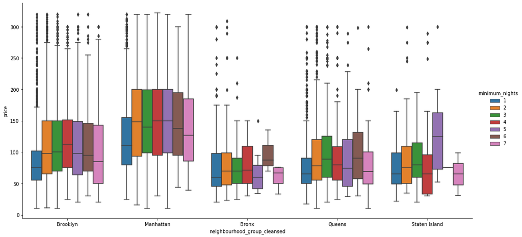

```python
sns.catplot(x='neighbourhood_group_cleansed', y='price',
            data=listings_explore, kind='box',
            hue='minimum_nights', height=7, aspect=2)
plt.show()
```

## Census Data

Lets pull some more insights from census.gov (2017): (https://www.census.gov/quickfacts/fact/table/newyorkcountymanhattanboroughnewyork,bronxcountybronxboroughnewyork,queenscountyqueensboroughnewyork,kingscountybrooklynboroughnewyork,richmondcountystatenislandboroughnewyork,newyorkcitynewyork#) (https://www.baruch.cuny.edu/nycdata/income-taxes/hhold_income-numbers.htm)

```python
# Create dataframe of NYC stats
#nyc_stats = pd.DataFrame(data={'neighbourhood': ['Manhattan', 'Bronx', 'Queens', 'Brooklyn', 'Staten Island']})
#nyc_stats = nyc_stats
nyc_stats = pd.DataFrame(data={'Brooklyn': [944650, 52782], 'Manhattan': [758345, 79781], 'Bronx': [495356, 36593], 'Queens': [777904, 62008], 'Staten_Island': [166150, 76244]},
             index=['households', 'median_household_income'])
nyc_stats = nyc_stats.append(pd.DataFrame(data=
            {'Brooklyn': [len(listings_explore[listings_explore.neighbourhood_group_cleansed == 'Brooklyn'])],
            'Manhattan': [len(listings_explore[listings_explore.neighbourhood_group_cleansed == 'Manhattan'])],
            'Bronx': [len(listings_explore[listings_explore.neighbourhood_group_cleansed == 'Bronx'])],
            'Queens': [len(listings_explore[listings_explore.neighbourhood_group_cleansed == 'Queens'])],
            'Staten_Island': [len(listings_explore[listings_explore.neighbourhood_group_cleansed == 'Staten Island'])]},
            index=['total_listings']))
nyc_stats.loc['households_per_listing'] = (nyc_stats.loc['households'].values / nyc_stats.loc['total_listings'])
nyc_stats = nyc_stats.append(pd.DataFrame(data=
            {'Brooklyn': [listings_explore[listings_explore.neighbourhood_group_cleansed == 'Brooklyn'].price.median()],
            'Manhattan': [listings_explore[listings_explore.neighbourhood_group_cleansed == 'Manhattan'].price.median()],
            'Bronx': [listings_explore[listings_explore.neighbourhood_group_cleansed == 'Bronx'].price.median()],
            'Queens': [listings_explore[listings_explore.neighbourhood_group_cleansed == 'Queens'].price.median()],
            'Staten_Island': [listings_explore[listings_explore.neighbourhood_group_cleansed == 'Staten Island'].price.median()]},
            index=['median_listing_price']))
nyc_stats = nyc_stats.append(pd.DataFrame(data=
            {'Brooklyn': [listings_explore[listings_explore.neighbourhood_group_cleansed == 'Brooklyn'].price.sum()],
            'Manhattan': [listings_explore[listings_explore.neighbourhood_group_cleansed == 'Manhattan'].price.sum()],
            'Bronx': [listings_explore[listings_explore.neighbourhood_group_cleansed == 'Bronx'].price.sum()],
            'Queens': [listings_explore[listings_explore.neighbourhood_group_cleansed == 'Queens'].price.sum()],
            'Staten_Island': [listings_explore[listings_explore.neighbourhood_group_cleansed == 'Staten Island'].price.sum()]},
            index=['total_revenue']))

nyc_stats = nyc_stats.round(0).astype('int').T
nyc_stats['neighbourhood'] = ['Brooklyn', 'Manhattan', 'Bronx', 'Queens', 'Staten Island']
cols = nyc_stats.columns.tolist()
cols = [cols[-1]] + cols[:-1]
nyc_stats = nyc_stats[cols]
nyc_stats
```

|  | neighbourhood | households | median_household_income | total_listings | households_per_listing | median_listing_price | total_revenue |
| --- | --- | --- | --- | --- | --- | --- | --- |
| Brooklyn | Brooklyn | 944650 | 52782 | 8527 | 111 | 91 | 918807 |
| Manhattan | Manhattan | 758345 | 79781 | 7212 | 105 | 130 | 1041371 |
| Bronx | Bronx | 495356 | 36593 | 551 | 899 | 65 | 42506 |
| Queens | Queens | 777904 | 62008 | 2725 | 285 | 70 | 240647 |
| Staten_Island | Staten Island | 166150 | 76244 | 217 | 766 | 75 | 18769 |

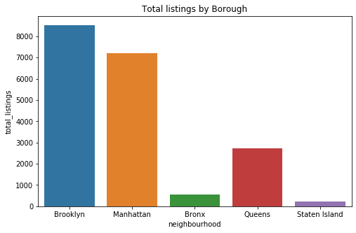

```python
plt.figure(figsize=(8,5))
sns.barplot(x='neighbourhood', y='total_listings', data=nyc_stats)
plt.title('Total listings by Borough')
plt.show()
```

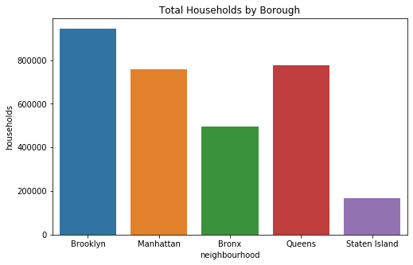

```python
plt.figure(figsize=(8,5))
sns.barplot(x='neighbourhood', y='households', data=nyc_stats)
plt.title('Total Households by Borough')
plt.show()
```

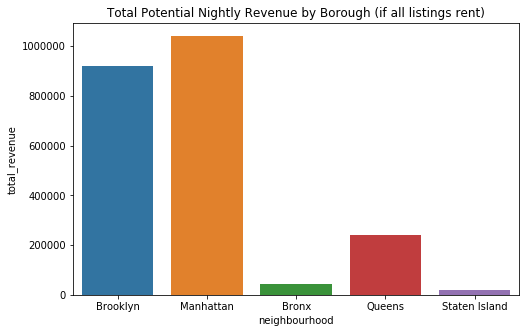

```python
plt.figure(figsize=(8,5))
sns.barplot(x='neighbourhood', y='total_revenue', data=nyc_stats)
plt.title('Total Potential Nightly Revenue by Borough (if all listings rent)')
plt.show()
```

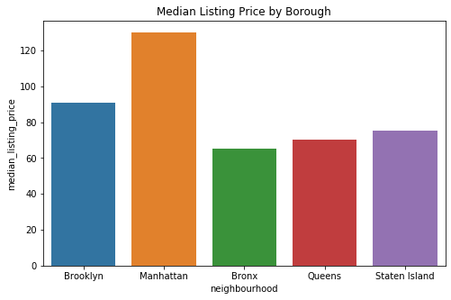

```python
plt.figure(figsize=(8,5))
sns.barplot(x='neighbourhood', y='median_listing_price', data=nyc_stats)
plt.title('Median Listing Price by Borough')
plt.show()
```

```python
nyc_stats
```

|  | neighbourhood | households | median_household_income | total_listings | households_per_listing | median_listing_price | total_revenue |
| --- | --- | --- | --- | --- | --- | --- | --- |
| Brooklyn | Brooklyn | 944650 | 52782 | 8527 | 111 | 91 | 918807 |
| Manhattan | Manhattan | 758345 | 79781 | 7212 | 105 | 130 | 1041371 |
| Bronx | Bronx | 495356 | 36593 | 551 | 899 | 65 | 42506 |
| Queens | Queens | 777904 | 62008 | 2725 | 285 | 70 | 240647 |
| Staten_Island | Staten Island | 166150 | 76244 | 217 | 766 | 75 | 18769 |

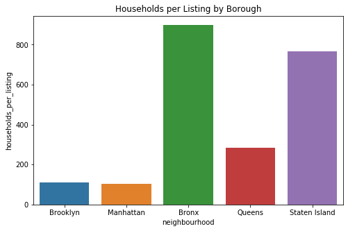

```python
plt.figure(figsize=(8,5))
sns.barplot(x='neighbourhood', y='households_per_listing', data=nyc_stats)
plt.title('Households per Listing by Borough')
plt.show()
```

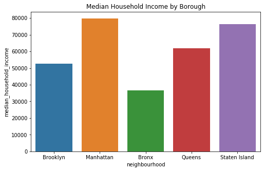

```python
plt.figure(figsize=(8,5))
sns.barplot(x='neighbourhood', y='median_household_income', data=nyc_stats)
plt.title('Median Household Income by Borough')
plt.show()
```

## Which Airbnb's do guests prefer?

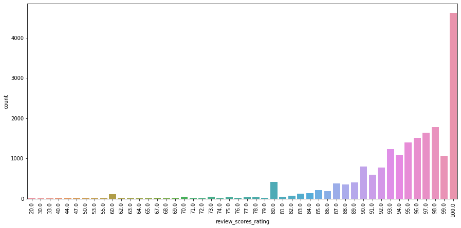

```python
plt.figure(figsize=(15,7))
ax = sns.countplot(listings_explore.review_scores_rating.round(0))
ax.set_xticklabels(ax.get_xticklabels(), rotation=90)
plt.show()
```

```python
# Percentage of listings with score >= 90
100 - percentile(listings_explore.review_scores_rating, 89)
```

```
86.74344841930116
```

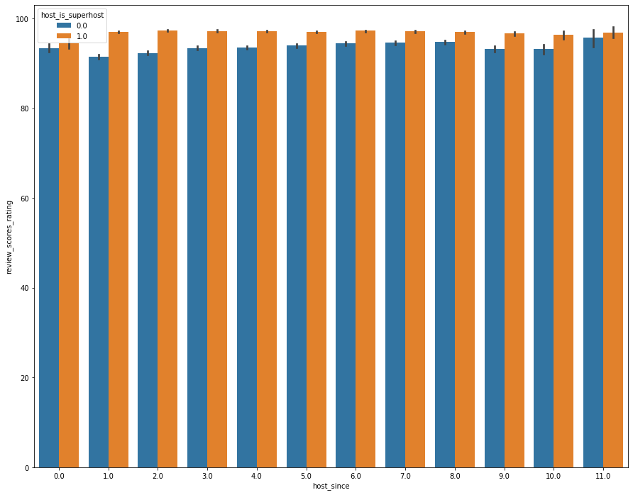

```python
plt.figure(figsize=(15,12))
sns.barplot(x='host_since', y='review_scores_rating', hue='host_is_superhost', data=listings_explore)
plt.show()
```

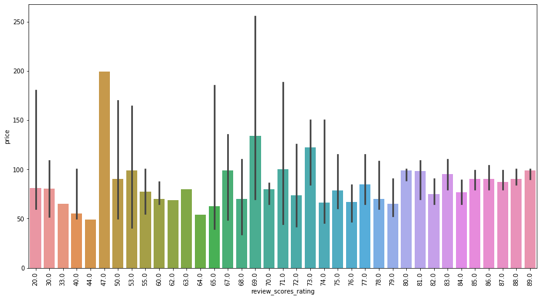

```python
plt.figure(figsize=(15,8))
ax = sns.barplot(x='review_scores_rating', y='price',# hue='neighbourhood_group_cleansed',
                 data=listings_explore[listings_explore.review_scores_rating<90], estimator=median)
ax.set_xticklabels(ax.get_xticklabels(), rotation=90)
plt.show()
```

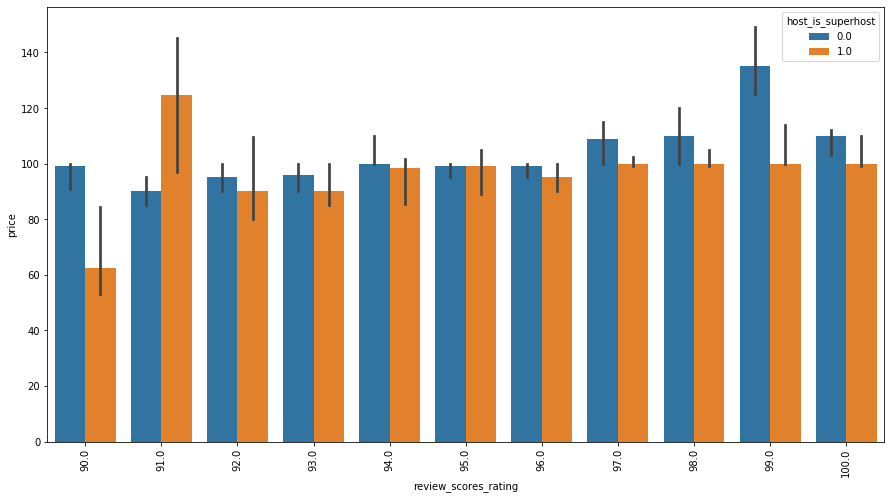

```python
plt.figure(figsize=(15,8))
ax = sns.barplot(x=listings_explore[listings_explore.review_scores_rating>=90].review_scores_rating.round(0),
                 y=listings_explore[listings_explore.review_scores_rating>=90].price,
                 hue=listings_explore[listings_explore.review_scores_rating>=90].host_is_superhost,
                 estimator=median)
ax.set_xticklabels(ax.get_xticklabels(), rotation=90)
plt.show()
```

Now that we have finished our analysis, we will remove the features with high multicollinearity from our correlation heatmaps to prepare the DataFrame for our machine learning models.

```python
listings_explore.drop(columns=corr_drop, inplace=True)
dropped_cols.extend(corr_drop)

# remove items from attribute lists
for attrib in corr_drop:
    try:
        num_attribs.remove(attrib)
    except ValueError:
        pass
for attrib in corr_drop:
    try:
        disc_attribs.remove(attrib)
    except ValueError:
        pass
for attrib in corr_drop:
    try:
        cat_attribs.remove(attrib)
    except ValueError:
        pass
for attrib in corr_drop:
    try:
        amen_attribs.remove(attrib)
    except ValueError:
        pass
```

# Preparing Training Set for ML Models.

```python
# drop price (label) from num_attribs list
num_attribs.remove('price')
```

We will now create a function to clean any dataframe based on the preprocessing performed above. This way, any new data can be cleansed through this function in the future, including the test set.

```python
# Function to clean dataframe
def clean_listings(df):
    '''
    Cleans listings dataframe to prepare for ML models.

    Args:
    df -- uncleaned listings dataframe

    Returns:
    clean_df -- cleaned listings dataframe'''

    # 1. Price (string mod, cut)

    # Remove string characters, convert to float
    df['price'] = df['price'].astype('str')
    df['price'] = df['price'].str.replace('.00', '', regex=False)
    df['price'] = df['price'].str.replace('$', '', regex=False)
    df['price'] = df['price'].str.replace(',', '', regex=False)
    df['price'] = df['price'].astype('float64')

    # Only include price in range [10, 323]
    df = df[(df.price < 323) & (df.price >= 10)]

    # 2. number_of_reviews_ltm (cut)

    # Only include number_of_reviews_ltm > 0
    df = df[df.number_of_reviews_ltm > 0]

    # 3. host_since (string mod)

    # Convert to how many years host
    df['host_since'] = 2019 - df['host_since'].str[:4].astype('float64')

    # 4. cleaning_fee (string mod)

    # Remove string characters, convert to float
    df['cleaning_fee'] = df.cleaning_fee.str.replace('$', '', regex=False)
    df['cleaning_fee'] = df.cleaning_fee.str.replace('.00', '', regex=False)
    df['cleaning_fee'] = df.cleaning_fee.str.replace(',', '', regex=False)
    df['cleaning_fee'] = df.cleaning_fee.astype('float64')

    # 5. extra_people (string mod)

    # Remove string characters, convert to float
    df['extra_people'] = df.extra_people.str.replace('$', '', regex=False)
    df['extra_people'] = df.extra_people.str.replace('.00', '', regex=False)
    df['extra_people'] = df.extra_people.str.replace(',', '', regex=False)
    df['extra_people'] = df.extra_people.astype('float64')

    # 6. minimum_nights (cut)

    # only include minimum_nights <= 7
    df = df[df.minimum_nights <= 7].copy()

    # 7. maximum_nights (cap)

    # Cap maximum_nights at 1125
    df['maximum_nights'].values[df.maximum_nights > 180] = 180

    # 8. host_is_superhost (convert to 1/0)

    # Convert t/f to 1/0
    df['host_is_superhost'] = convert_tf(df, 'host_is_superhost')

    # 9. host_identity_verified (convert to 1/0) # column is in drop_later actually

    # Convert t/f to 1/0
    #df['host_identity_verified'] = convert_tf(df, 'host_identity_verified')

    # 10. property_type (filter)

    # Filter specific property types
    df = df[
                           (df.property_type == 'Apartment') |
                           (df.property_type == 'House') |
                           (df.property_type == 'Condominium') |
                           (df.property_type == 'Townhouse') |
                           (df.property_type == 'Guest suite') |
                           (df.property_type == 'Guesthouse') |
                           (df.property_type == 'Loft') |
                           (df.property_type == 'Serviced apartment') |
                           (df.property_type == 'Tiny house') |
                           (df.property_type == 'Earth house') |
                           (df.property_type == 'Villa') |
                           (df.property_type == 'Castle') |
                           (df.property_type == 'Cottage') |
                           (df.property_type == 'Dome house')]

    # 11. amenities (cut, string mod)

    # Remove empty values ({})
    df = df[df.amenities != '{}']

    # Remove brackets and quotes, split by ','
    df['amenities'] = df.amenities.astype('str').str.replace('{', '', regex=False).copy()
    df['amenities'] = df.amenities.str.replace('}', '', regex=False).copy()
    df['amenities'] = df.amenities.str.replace('"', '', regex=False).copy()
    df['amenities'] = df.amenities.str.split(',').copy()

    # 12. instant_bookable (convert to 1/0)

    # Convert t/f to 1/0
    df['instant_bookable'] = convert_tf(df, 'instant_bookable')

    # 13. require_guest_profile_picture (convert to 1/0)

    # Convert t/f to 1/0
    df['require_guest_profile_picture'] = convert_tf(df, 'require_guest_profile_picture')

    # 14. amenities (multilabelbinarizer)

    # Create columns for each amenity using MultiLabelBinarizer
    from sklearn.preprocessing import MultiLabelBinarizer

    mlb = MultiLabelBinarizer()
    amenities_df = pd.DataFrame(mlb.fit_transform(df.amenities))
    classes = mlb.classes_ # amenity names
    amenities_df.columns = classes # add amenity names as columns

    # Save indices
    indices = np.array(df.index)

    # Merge new amenities columns with original dataframe
    df = pd.concat([df.reset_index(drop=True), amenities_df.reset_index(drop=True)], axis=1)

    # Reapply original indices
    df = df.set_index(indices)

    # Drop 'amenities' column
    df.drop(columns='amenities', inplace=True)

    # Drop unused amenities
    df.drop(columns=dropped_amenities, inplace=True)

    #15. LabelEncoder for string-type categories
    from sklearn.preprocessing import LabelEncoder
    le = LabelEncoder()
    for col in ['neighbourhood_cleansed',
                'neighbourhood_group_cleansed',
                'property_type',
                'room_type',
                'bed_type',
                'cancellation_policy']:
        le.fit(df[col])
        df[col] = le.transform(df[col])

    #16. Drop unused features
    df.drop(columns=(dropped_cols+drop_later), inplace=True)

    return df
```

```python
# Clean Training Data
listings_prepared = clean_listings(listings_train)
```

[output not shown]

Remove label feature from training data.

```python
# create y_train from label, drop label from listings_prepared
y_train = listings_prepared['price']
listings_prepared.drop(columns='price', inplace=True)
```

```python
# Confirm y_train values correct
print(len(y_train))
print(len(listings_prepared))
y_train[0:5]
```

```
19232
19232
```

```
37753     85.0
3719     285.0
6355     110.0
44513     60.0
39362     50.0
Name: price, dtype: float64
```

```python
# Compare shape of listings_explore and listings_prepared
print(listings_explore.shape) # +2 cols in drop_later, +1 col is price
print(listings_prepared.shape)
```

```
(19232, 65)
(19232, 62)
```

```python
# Check missing values
sum(listings_prepared.isnull().sum())
```

```
3041
```

## Transformation Pipelines

We will now create transformation Pipelines to scale, missing value impute, and one hot encode the data based on data type, and run it through the training data using ColumnTransformer. These pipelines can later be used to transform the test data as well.

```python
# Create pipelines
from sklearn.impute import SimpleImputer
from sklearn.preprocessing import StandardScaler
from sklearn.preprocessing import OneHotEncoder
from sklearn.pipeline import Pipeline

num_pipeline = Pipeline([
    ('num_imputer', SimpleImputer(strategy='median')),
    ('num_scaler', StandardScaler()),
])

disc_pipeline = Pipeline([
    ('disc_imputer', SimpleImputer(strategy='most_frequent')),
    ('disc_scaler', StandardScaler()),
])

cat_pipeline = Pipeline([
    ('cat_imputer', SimpleImputer(strategy='most_frequent')),
    ('cat_ohe', OneHotEncoder(categories='auto', drop='first',
                              sparse=False)),
])

amen_pipeline= Pipeline([
    ('amen_imputer', SimpleImputer(strategy='most_frequent')),
])
```

```python
# Create X_train from ColumnTransformer
from sklearn.compose import ColumnTransformer

listings_prepared_pipeline = listings_prepared.copy()
listings_pipeline = ColumnTransformer([
    ('num', num_pipeline, num_attribs),
    ('disc', disc_pipeline, disc_attribs),
    ('cat', cat_pipeline, cat_attribs),
    ('amen', amen_pipeline, amen_attribs),
])
X_train = listings_pipeline.fit_transform(listings_prepared_pipeline)
```

We will also create a separate X_train_trees for tree-based algorithms using only LabelEncoder, not OneHotEncoder for non-binary categories. Tree-based algorithms often perform better on data with less binary columns.

```python
# remove OneHotEncoder from cat_pipeline
cat_pipeline_trees = Pipeline([
    ('cat_imputer_trees', SimpleImputer(strategy='most_frequent')),
])
```

```python
# X_train_trees
listings_prepared_trees = listings_prepared.copy()
listings_pipeline_trees = ColumnTransformer([
    ('num_trees', num_pipeline, num_attribs),
    ('disc_trees', disc_pipeline, disc_attribs),
    ('cat_trees', cat_pipeline_trees, cat_attribs),
    ('amen_trees', amen_pipeline, amen_attribs),
])
X_train_trees = listings_pipeline_trees.fit_transform(listings_prepared_trees)
```

```python
# Confirm for no missing values in X_train and X_train_trees
print(sum(pd.DataFrame(X_train).isnull().sum()))
print(sum(pd.DataFrame(X_train_trees).isnull().sum()))
```

```
0
0
```

```python
# Confirm shape
print(X_train_trees.shape)
print(listings_prepared.shape)
```

```
(19232, 62)
(19232, 62)
```

# SelectKBest Feature Importance (Top 10)

Here, we use the SelectKBest method to choose the top 10 most important features. We will then create training data for the top 10 features, and compare our model results with the results of the full training data.

```python
# SelectKBest Feature Selection
from sklearn.feature_selection import SelectKBest
from sklearn.feature_selection import f_regression

# X_train's column names
X_train_cols = (num_attribs+disc_attribs+cat_attribs+amen_attribs)

# Create X and y
X = pd.DataFrame(X_train_trees, columns=X_train_cols).copy()
y = y_train.copy()

# Fit SelectKBest with k=10
best_features = SelectKBest(score_func=f_regression, k=10)
fit = best_features.fit(X,y)

# Create DataFrames for scores and features (columns)
df_fscores = pd.DataFrame(fit.scores_, columns=['f-score'])
df_pvals = pd.DataFrame(fit.pvalues_, columns=['p-value'])
df_columns = pd.DataFrame(X.columns, columns=['Feature'])

# concat two dataframes for better visualization
featureScores = pd.concat([df_columns,df_fscores,df_pvals], axis=1)
featureScores.columns = ['Feature', 'F-score', 'p-value'] # naming the dataframe columns
featureScores.sort_values(by='F-score', ascending=False).head(10)
```

[output not shown]

```python
# Get top 10 features
top_10 = list(featureScores[featureScores['F-score'] >= 637]['Feature'])
top_10
```

```
['longitude',
 'cleaning_fee',
 'accommodates',
 'bedrooms',
 'beds',
 'guests_included',
 'room_type',
 'Air conditioning',
 'Family/kid friendly',
 'TV']
```

```python
# Modify attrib lists for Top 10
import collections

# num_attribs_10
num_test = top_10 + num_attribs
num_attribs_10 = []
num_attribs_10.extend([item for item, count in collections.Counter(num_test).items() if count > 1])
print(num_attribs_10)

# disc_attribs_10
disc_test = top_10 + disc_attribs
disc_attribs_10 = []
disc_attribs_10.extend([item for item, count in collections.Counter(disc_test).items() if count > 1])
print(disc_attribs_10)

#cat_attribs_10
cat_test = (top_10 + cat_attribs)
cat_attribs_10 = []
cat_attribs_10.extend([item for item, count in collections.Counter(cat_test).items() if count > 1])
print(cat_attribs_10)

#amen_attribs_10
amen_test = (top_10 + amen_attribs)
amen_attribs_10 = []
amen_attribs_10.extend([item for item, count in collections.Counter(amen_test).items() if count > 1])
print(amen_attribs_10)
```

```
['longitude', 'cleaning_fee']
['accommodates', 'bedrooms', 'beds', 'guests_included']
['room_type']
['Air conditioning', 'Family/kid friendly', 'TV']
```

```python
# Create new pipelines and ColumnTransformer for Top 10

# Create pipelines (X_train)
from sklearn.impute import SimpleImputer
from sklearn.preprocessing import StandardScaler
from sklearn.preprocessing import OneHotEncoder
from sklearn.pipeline import Pipeline

num_pipeline_ = Pipeline([
    ('num_imputer', SimpleImputer(strategy='median')),
    ('num_scaler', StandardScaler()),
])

disc_pipeline_ = Pipeline([
    ('disc_imputer', SimpleImputer(strategy='most_frequent')),
    ('disc_scaler', StandardScaler()),
])

cat_pipeline_ = Pipeline([
    ('cat_imputer', SimpleImputer(strategy='most_frequent')),
    ('cat_ohe_10', OneHotEncoder(categories='auto', drop='first',
                              sparse=False)),
])

amen_pipeline_ = Pipeline([
    ('amen_imputer', SimpleImputer(strategy='most_frequent')),
])

# Create X_train from ColumnTransformer
from sklearn.compose import ColumnTransformer

listings_prepared_pipeline_ = listings_prepared.copy()
listings_pipeline = ColumnTransformer([
    ('num', num_pipeline_, num_attribs_10),
    ('disc', disc_pipeline_, disc_attribs_10),
    ('cat', cat_pipeline_, cat_attribs_10),
    ('amen', amen_pipeline_, amen_attribs_10),
])
X_train_10 = listings_pipeline.fit_transform(listings_prepared_pipeline)

# remove OneHotEncoder from cat_pipeline
cat_pipeline_trees = Pipeline([
    ('cat_imputer_trees', SimpleImputer(strategy='most_frequent')),
])

# X_train_trees_10
listings_prepared_trees_10 = listings_prepared.copy()
listings_pipeline_trees_10 = ColumnTransformer([
    ('num_trees', num_pipeline, num_attribs_10),
    ('disc_trees', disc_pipeline, disc_attribs_10),
    ('cat_trees_10', cat_pipeline_trees, cat_attribs_10),
    ('amen_trees', amen_pipeline, amen_attribs_10),
])
X_train_trees_10 = listings_pipeline_trees_10.fit_transform(listings_prepared_trees_10)
```

# Machine Learning Algorithms

```python
# Split training set into validation and train sets
X_train_val, X_val, y_train_val, y_val = train_test_split(X_train.copy(), y_train.copy(),
                                                        test_size=0.2, random_state=42)
# Trees data
X_train_trees_val, X_val_trees, y_train_trees_val, y_val_trees = train_test_split(X_train_trees.copy(), y_train.copy(),
                                                                                test_size=0.2, random_state=42)
```

```python
# Run Model function
def run_model(model, X_train, y_train):
    '''
    Function to run models and output RMSE.

    Args:
    model -- model with parameters
    X_train -- X_train
    y_train -- y_train

    Return:
    rmse -- root mean squared error
    run_time -- model run time'''

    start_time = time.time() # Timing

    # Model
    model.fit(X_train, y_train)
    y_pred = model.predict(X_train)

    # Metrics
    from sklearn.metrics import mean_squared_error
    from sklearn.metrics import r2_score
    rmse = np.round(np.sqrt(mean_squared_error(y_train, y_pred)), 4)
    r2 = np.round(r2_score(y_train, y_pred), 4)
    print('RMSE:', rmse)
    print('r2:', r2)

    # Timing
    run_time = (time.time() - start_time)
    print('Running Time: {}'.format(datetime.timedelta(seconds=run_time)))

    return rmse, r2, run_time
```

```python
def run_model_cv(model, X_train, y_train, cv=10):
    '''
    Function to run cross_val_score on a model.

    Args:
    model -- model with parameters
    X_train -- X_train
    y_train -- y_train

    Return:
    cv_scores -- RMSE scores of each k-fold
    run_time'''

    start_time = time.time() # Timing
    from sklearn.model_selection import cross_validate

    scoring = {'RMSE': 'neg_mean_squared_error',
               'r2': 'r2'}
    scores = cross_validate(model, X_train, y_train, scoring=scoring,
                             cv=cv, return_train_score=False)
    rmse = np.round(np.mean(np.sqrt(-scores['test_RMSE'])), 4)
    r2 = np.round(np.mean(scores['test_r2']), 4)
    print('RMSE CV:', rmse)
    print('r2 CV:', r2)

    # Timing
    run_time = (time.time() - start_time)
    print('Running Time: {}'.format(datetime.timedelta(seconds=run_time)))

    return rmse, r2
```

[output not shown]

```python
# RandomSearchCV
def random_search(est, params, nbr_iter, X_train, y_train, cv=10):
    start_time = time.time() # Timing
    from sklearn.model_selection import RandomizedSearchCV
    rdmsearch = RandomizedSearchCV(est, param_distributions=params,
                                   scoring='neg_mean_squared_error',
                                   n_iter=nbr_iter, cv=cv)
    rdmsearch.fit(X_train, y_train)
    best_params = rdmsearch.best_params_
    best_estimator = rdmsearch.best_estimator_
    best_score = rdmsearch.best_score_
    print('Best RMSE:', np.sqrt(-best_score))
    print(best_params)
    # Timing
    run_time = (time.time() - start_time)
    print('Running Time: {}'.format(datetime.timedelta(seconds=run_time)))
    return rdmsearch, best_estimator
```

```python
# Plot Learning Curves function
from sklearn.metrics import mean_squared_error
from sklearn.model_selection import train_test_split
def plot_learning_curves(model, X, y):
    X_train, X_val, y_train, y_val = train_test_split(X, y, test_size=0.2, random_state=42)
    train_errors, val_errors = [], []
    for m in range(1, len(X_train)):
        model.fit(X_train[:m], y_train[:m])
        y_train_predict = model.predict(X_train[:m])
        y_val_predict = model.predict(X_val)
        train_errors.append(mean_squared_error(y_train[:m], y_train_predict))
        val_errors.append(mean_squared_error(y_val, y_val_predict))

    plt.plot(np.sqrt(train_errors), "r-+", linewidth=2, label="train")
    plt.plot(np.sqrt(val_errors), "b-", linewidth=3, label="val")
    plt.legend(loc="upper right", fontsize=14)
    plt.xlabel("Training set size", fontsize=14)
    plt.ylabel("RMSE", fontsize=14)
```

## Linear Regression

```python
# Linear Regression Model
from sklearn.linear_model import LinearRegression
lin_reg = LinearRegression()
# Run Model
lin_reg_rmse, lin_reg_r2, lin_reg_time = run_model(lin_reg, X_train, y_train)
print()
# Run Model CV
lin_reg_rmse_cv, lin_reg_r2_cv = run_model_cv(lin_reg, X_train, y_train)
```

```
RMSE: 36.4627
r2: 0.6924
Running Time: 0:00:00.516028

RMSE CV: 62120873432.1528
r2 CV: -6.071130849190576e+18
Running Time: 0:00:04.484702
```

```python
# Linear Regression Model Top 10
from sklearn.linear_model import LinearRegression
lin_reg_10 = LinearRegression()
# Run Model
lin_reg_10_rmse, lin_reg_10_r2, lin_reg_10_time = run_model(lin_reg, X_train_10, y_train)
print()
# Run Model CV
lin_reg_10_rmse_cv, lin_reg_10_r2_cv = run_model_cv(lin_reg, X_train_10, y_train)
```

```
RMSE: 44.2512
r2: 0.547
Running Time: 0:00:00.014880

RMSE CV: 44.2857
r2 CV: 0.5455
Running Time: 0:00:00.105575
```

Let's try out some polynomial features. We will only run for top 10 due to dimensionality constraints.

```python
# Polynomial Linear Regression Top 10 (deg 2 was 43.0661/43.3208)
from sklearn.preprocessing import PolynomialFeatures
poly_features = PolynomialFeatures(degree=3, include_bias=False)
X_poly_10 = poly_features.fit_transform(X_train_10)
lin_reg_poly_10 = LinearRegression()

# Run Model
lin_reg_poly_10_rmse, lin_reg_poly_10_r2, lin_reg_poly_10_time = run_model(lin_reg_poly_10, X_poly_10, y_train)
print()
# Run Model CV
lin_reg_poly_10_rmse_cv, lin_reg_poly_10_r2_cv = run_model_cv(lin_reg_poly_10, X_poly_10, y_train)
```

```
RMSE: 41.1676
r2: 0.6079
Running Time: 0:00:00.636256

RMSE CV: 43.148
r2 CV: 0.5682
Running Time: 0:00:04.052256
```

# Stochastic Gradient Descent

```python
# SGD Model
from sklearn.linear_model import SGDRegressor
sgd = SGDRegressor()
# Run Model
sgd_rmse, sgd_r2, sgd_time = run_model(sgd, X_train, y_train)
print()
# Run Model CV
sgd_rmse_cv, sgd_r2_cv = run_model_cv(sgd, X_train, y_train)
```

```
RMSE: 36.8065
r2: 0.6866
Running Time: 0:00:01.576715

RMSE CV: 37.2353
r2 CV: 0.6787
Running Time: 0:00:10.612077
```

```python
# SGD Model Top 10
from sklearn.linear_model import SGDRegressor
sgd_10 = SGDRegressor()

# Run Model
sgd_10_rmse, sgd_10_r2, sgd_10_time = run_model(sgd_10, X_train_10, y_train.ravel())
print()
# Run Model CV
sgd_10_rmse_cv, sgd_10_r2_cv = run_model_cv(sgd_10, X_train_10, y_train)
```

```
RMSE: 44.3245
r2: 0.5455
Running Time: 0:00:00.060280

RMSE CV: 44.3124
r2 CV: 0.545
Running Time: 0:00:00.711876
```

```python
'''# RandomSearchCV
sgd_param_grid = {
    max_iter =
        }
sgd_best_params, sgd_best_score = random_search()'''
```

```
'# RandomSearchCV\nsgd_param_grid = {\n    max_iter =\n        }\nsgd_best_params, sgd_best_score = random_search()'
```

SGDRegressor(max_iter=5000, tol=1e-3, penalty='l2', alpha=0.0002, eta0=0.00001, random_state=42)

```python
'''# Polynomial SGD Regression
from sklearn.preprocessing import PolynomialFeatures
poly_features = PolynomialFeatures(degree=2, include_bias=False)
X_poly = poly_features.fit_transform(X_train)

# Run Model
sgd_reg_poly = SGDRegressor(max_iter=5000, tol=1e-3, penalty='l2',
                            alpha=0.0002, eta0=0.00001,
                            random_state=42)
sgd_reg_poly, sgd_reg_poly_time = run_model(sgd_reg, X_poly, y_train)
print()
sgd_reg_poly_cv = run_model_cv(sgd_reg, X_poly, y_train)'''
```

```
"# Polynomial SGD Regression\nfrom sklearn.preprocessing import PolynomialFeatures\npoly_features = PolynomialFeatures(degree=2, include_bias=False)\nX_poly = poly_features.fit_transform(X_train)\n\n# Run Model\nsgd_reg_poly = SGDRegressor(max_iter=5000, tol=1e-3, penalty='l2',\n                    …
```

For now, SGDRegressor with full features performs best at RMSE 36 and CV at 37.

# KNN Regressor

```python
# KNN Model
from sklearn.neighbors import KNeighborsRegressor
knn = KNeighborsRegressor(n_neighbors=2)

# Run Model
knn_rmse, knn_r2, knn_time = run_model(KNeighborsRegressor(n_neighbors=2), X_train, y_train)
print()
# Run Model CV
knn_rmse_cv, knn_r2_cv = run_model_cv(knn, X_train, y_train, cv=5)
```

```
RMSE: 26.5359
r2: 0.8371
Running Time: 0:02:52.292211
```

```python
# KNN Model Top 10
from sklearn.neighbors import KNeighborsRegressor
knn_10 = KNeighborsRegressor(n_neighbors=4)

# Run Model
knn_10_rmse, knn_10_r2, knn_10_time = run_model(knn_10, X_train_10, y_train)
print()
# Run Model CV
knn_10_rmse_cv, knn_10_r2_cv = run_model_cv(knn_10, X_train_10, y_train, cv=5)
```

```
RMSE: 34.3149
r2: 0.7276
Running Time: 0:00:02.004422

RMSE CV: 44.7586
r2 CV: 0.536
Running Time: 0:00:03.298530
```

# Support Vector Machine Regressor

### Linear SVR

```python
# Linear SVR
from sklearn.svm import LinearSVR
lin_svr = LinearSVR(epsilon=0)

# Run Model
lin_svr_rmse, lin_svr_r2, lin_svr_time = run_model(lin_svr, X_train, y_train)
print()
# Run Model CV
lin_svr_rmse_cv, lin_svr_r2_cv = run_model_cv(lin_svr, X_train, y_train)
```

```
RMSE: 37.5309
r2: 0.6741
Running Time: 0:00:00.241921

RMSE CV: 37.7504
r2 CV: 0.6698
Running Time: 0:00:02.416786
```

```python
# Linear SVR Top 10
from sklearn.svm import LinearSVR
lin_svr_10 = LinearSVR(epsilon=0)

# Run Model
lin_svr_10_rmse, lin_svr_10_r2, lin_svr_10_time = run_model(lin_svr_10, X_train_10, y_train)
print()
# Run Model CV
lin_svr_10_rmse_cv, lin_svr_10_r2_cv = run_model_cv(lin_svr_10, X_train_10, y_train)
```

```
RMSE: 44.8149
r2: 0.5354
Running Time: 0:00:00.055051

RMSE CV: 44.849
r2 CV: 0.534
Running Time: 0:00:00.428582
```

### SVR Poly Kernel

Need to Random Search different degrees, C's, and epsilon's.

```python
# SVR Poly Kernel Top 10
from sklearn.svm import SVR
svr_poly_10 = SVR(kernel='poly', degree=2, C=100, epsilon=1, gamma='auto_deprecated')

# Run Model
svr_poly_10_rmse, svr_poly_10_r2, svr_poly_10_time = run_model(svr_poly_10, X_train_10, y_train)
print()
# Run Model CV
#svr_poly_10_rmse_cv, svr_poly_10_r2_cv = run_model_cv(svr_poly_10, X_train_10, y_train)
```

```
RMSE: 44.4849
r2: 0.5422
Running Time: 0:00:25.791952
```

# Decision Tree Regressor

- `max_depth`: restricts the maximum depth.
- `min_samples_split`: (the minimum number of samples a node must have before it can be split)
- `min_samples_leaf`: the minimum number of samples a leaf node must have), min_weight_fraction_leaf (same as `min_samples_leaf` but expressed as a fraction of the total number of weighted instances)
- `max_leaf_nodes`: maximum number of leaf nodes
- `max_features`: maximum number of features that are evaluated for splitting at each node

Increasing `min_*` hyperparameters or reducing `max_*` hyperparameters will regularize the model.

```python
# Decision Tree Regressor
from sklearn.tree import DecisionTreeRegressor

tree_reg = DecisionTreeRegressor(max_depth=5,
                                 random_state=42)
# Run Model
tree_reg_rmse, tree_reg_r2, tree_reg_time = run_model(tree_reg, X_train, y_train)
print()
# Run Model CV
tree_reg_rmse_cv, tree_reg_r2_cv = run_model_cv(tree_reg, X_train, y_train)
```

```
RMSE: 41.5669
r2: 0.6003
Running Time: 0:00:00.436686

RMSE CV: 42.4037
r2 CV: 0.5832
Running Time: 0:00:03.907876
```

```python
# Decision Tree Regressor Top 10
from sklearn.tree import DecisionTreeRegressor

tree_reg_10 = DecisionTreeRegressor(max_depth=9,
                                 random_state=42)
# Run Model
tree_reg_10_rmse, tree_reg_10_r2, tree_reg_10_time = run_model(tree_reg_10, X_train_10, y_train)
print()
# Run Model CV
tree_reg_10_rmse_cv, tree_reg_10_r2_cv = run_model_cv(tree_reg_10, X_train_10, y_train)
```

```
RMSE: 38.4633
r2: 0.6577
Running Time: 0:00:00.038549

RMSE CV: 42.7197
r2 CV: 0.577
Running Time: 0:00:00.365720
```

# Random Forest Regressor

- `max_depth`: restricts the maximum depth.
- `min_samples_split`: (the minimum number of samples a node must have before it can be split)
- `min_samples_leaf`: the minimum number of samples a leaf node must have), min_weight_fraction_leaf (same as `min_samples_leaf` but expressed as a fraction of the total number of weighted instances)
- `max_leaf_nodes`: maximum number of leaf nodes
- `max_features`: maximum number of features that are evaluated for splitting at each node

Increasing `min_*` hyperparameters or reducing `max_*` hyperparameters will regularize the model.

```python
# Random Forest Regressor
from sklearn.ensemble import RandomForestRegressor

forest = RandomForestRegressor(max_depth=4, n_estimators=100,
                               random_state=42)
# Run Model
forest_rmse, forest_r2, forest_time = run_model(forest, X_train_trees, y_train)
print()
# Run Model CV
forest_rmse_cv, forest_r2_cv = run_model_cv(forest, X_train_trees, y_train)
```

```
RMSE: 41.0618
r2: 0.6099
Running Time: 0:00:05.268000

RMSE CV: 41.4059
r2 CV: 0.6025
Running Time: 0:00:48.659276
```

```python
# Forest RandomSearchCV
from scipy.stats import randint

forest_rds = RandomForestRegressor(random_state=42)

forest_param_grid = {
    'max_depth':[1,2,3,4,10,None],
    'n_estimators':[100,200,300,400,500,'warn'],
    'max_features':randint(1,3),
    'bootstrap':[True,False],
    'min_samples_leaf':randint(1,4),
    }
forest_best_params, forest_best = random_search(forest, forest_param_grid,
                                        40, X_train_trees, y_train,
                                        cv=5)
```

[output not shown]

```
Best RMSE: 40.83688755774437
{'bootstrap': True, 'max_depth': None, 'max_features': 2, 'min_samples_leaf': 2, 'n_estimators': 500}
Running Time: 0:04:20.745161
```

```python
# Run Model
forest_rmse, forest_r2, forest_time = run_model(forest_best, X_train_trees, y_train)
print()
# Run Model CV
forest_rmse_cv, forest_r2_cv = run_model_cv(forest_best, X_train_trees, y_train)
```

```
RMSE: 30.3369
r2: 0.7871
Running Time: 0:00:08.643089

RMSE CV: 40.6184
r2 CV: 0.6178
Running Time: 0:01:06.430403
```

Get the feature importances for this and run a top 10 using those.

#### Feature importances:

```python
# Feature importances
sorted(zip(forest_best.feature_importances_, (num_attribs+disc_attribs+cat_attribs+amen_attribs)), reverse=True)
```

```
[(0.13696136802351028, 'room_type'),
 (0.09706199443127699, 'cleaning_fee'),
 (0.07381458913320153, 'longitude'),
 (0.07333891303393275, 'accommodates'),
 (0.05346460940310583, 'bedrooms'),
 (0.04334678947371745, 'beds'),
 (0.04320703620681815, 'latitude'),
 (0.03645147597253477, 'guests_included'),
 (0.028540745572728787, 'neighbourhood_group_cleansed'),
 (0.027868982288670654, 'neighbourhood_cleansed'),
 (0.02344993032810446, 'extra_people'),
 (0.02166740541467623, 'reviews_per_month'),
 (0.019951094327358292, 'availability_365'),
 (0.01905363369185293, 'review_scores_location'),
 (0.01894546570214999, 'number_of_reviews'),
 (0.018108503524256962, 'minimum_nights'),
 (0.016982503879657943, 'availability_30'),
 (0.01688087545200359, 'host_since'),
 (0.016693083942244228, 'review_scores_rating'),
 (0.016046333317848233, 'TV'),
 (0.013150365223255732, 'maximum_nights'),
 (0.012017174020976053, 'Family/kid friendly'),
 (0.009852172153284015, 'Dishwasher'),
 (0.009292612380759246, 'property_type'),
 (0.009002945280890693, 'bathrooms'),
 (0.008938469812184154, 'cancellation_policy'),
 (0.008922614681081378, 'Washer'),
 (0.008332982915485999, 'Free street parking'),
 (0.008297208215572225, 'Air conditioning'),
 (0.00791000461718593, 'Elevator'),
 (0.007247800728755098, 'Laptop friendly workspace'),
 (0.005637254915525698, 'Hair dryer'),
 (0.005591921609819737, 'instant_bookable'),
 (0.005576775368402266, 'Private entrance'),
 (0.005241777742219742, 'Kitchen'),
 (0.005118286531031791, 'Self check-in'),
 (0.004753294797624848, 'Shampoo'),
 (0.0046456375210153205, 'Iron'),
 (0.004609511996321443, 'Paid parking off premises'),
 (0.004580478760082426, 'Host greets you'),
 (0.0044999807888391995, 'Cooking basics'),
 (0.004313216853497969, 'Hot water'),
 (0.003995681096193507, 'review_scores_communication'),
 (0.003963428733235328, 'host_is_superhost'),
 (0.003766878793090881, 'Gym'),
 (0.0033964830502664005, '24-hour check-in'),
 (0.0030724886738675242, 'Hangers'),
 (0.0029856638241478996, 'Doorman'),
 (0.0029236370347111296, 'Pets allowed'),
 (0.002339486532376857, 'Patio or balcony'),
 (0.002254234960804875, 'Free parking on premises'),
 (0.001970287891662689, 'Garden or backyard'),
 (0.0018350147660261247, 'Smoking allowed'),
 (0.0018321887452459158, 'Crib'),
 (0.0012511625802197296, 'Paid parking on premises'),
 (0.0010488603774109055, 'Heating'),
 (0.0008649721113231217, 'Hot tub'),
 (0.0008245290805623862, 'bed_type'),
 (0.0007647508288191313, 'Essentials'),
 (0.0006591590865178954, 'Pool'),
 (0.0004510455234559856, 'Wifi'),
 (0.0004322262766009133, 'Waterfront')]
```

```python
# Random Forest Regressor Top 10
from sklearn.ensemble import RandomForestRegressor

forest_10 = RandomForestRegressor(max_depth=4, n_estimators=100,
                               random_state=42)
# Run Model
forest_10_rmse, forest_10_r2, forest_10_time = run_model(forest_10, X_train_trees_10, y_train)
print()
# Run Model CV
forest_10_rmse_cv, forest_10_r2_cv = run_model_cv(forest_10, X_train_trees_10, y_train)
```

```
RMSE: 42.5629
r2: 0.5809
Running Time: 0:00:01.246026

RMSE CV: 42.9262
r2 CV: 0.5729
Running Time: 0:00:12.079485
```

Random Search CV with params listed above. Can also do baggingregressor and/or votingregressor once we've tuned a few good models to make them even better.

# AdaBoost Regressor

If overfitting, reduce n_estimators or more strongly regularize base estimator.

```python
# Adaboost
from sklearn.ensemble import AdaBoostRegressor
from sklearn.tree import DecisionTreeRegressor

ada_reg = AdaBoostRegressor(DecisionTreeRegressor(max_depth=5,
                                                  random_state=42),
                            n_estimators=200,
                            loss='linear', random_state=42)
# Run Model
ada_reg_rmse, ada_reg_r2, ada_reg_time = run_model(ada_reg, X_train_trees, y_train)
print()
# Run Model CV
ada_reg_rmse_cv, ada_reg_r2_cv = run_model_cv(ada_reg, X_train_trees, y_train)
```

```
RMSE: 48.0543
r2: 0.4658
Running Time: 0:00:22.313480

RMSE CV: 48.9882
r2 CV: 0.443
Running Time: 0:03:02.275905
```

RandomSearchCV on Decision Tree and then gridsearch on n_estimators.

```python
# Adaboost Top 10
from sklearn.ensemble import AdaBoostRegressor
from sklearn.tree import DecisionTreeRegressor

ada_reg_10 = AdaBoostRegressor(DecisionTreeRegressor(max_depth=9,
                                                  random_state=42),
                            n_estimators=200,
                            loss='linear', random_state=42)
# Run Model
ada_reg_10_rmse, ada_reg_10_r2, ada_reg_10_time = run_model(ada_reg_10, X_train_trees_10, y_train)
print()
# Run Model CV
ada_reg_10_rmse_cv, ada_reg_10_r2_cv = run_model_cv(ada_reg_10, X_train_trees_10, y_train)
```

```
RMSE: 50.0634
r2: 0.4202
Running Time: 0:00:06.467893

RMSE CV: 50.4637
r2 CV: 0.409
Running Time: 0:00:55.196276
```

# XGBoost Regressor

```python
# XGB
import xgboost
xgb = xgboost.XGBRegressor(max_depth=5, objective='reg:squarederror')

# Run Model
xgb_rmse, xgb_r2, xgb_time = run_model(xgb, X_train_trees, y_train)
print()
# Run Model CV
xgb_rmse_cv, xgb_r2_cv = run_model_cv(xgb, X_train_trees, y_train)
```

```
RMSE: 30.7555
r2: 0.7812
Running Time: 0:00:10.090574
```

```
RMSE CV: 34.7602
r2 CV: 0.72
Running Time: 0:01:34.757007
```

```python
# XGB RandomSearchCV
xgb = xgboost.XGBRegressor(objective='reg:squarederror')
xgb_param_grid = {
    'learning_rate': [0.05, 0.10, 0.15, 0.20, 0.25, 0.30],
    'max_depth': [3,4,5,6,8,10,12,15],
    'gamma': [0.0,0.1,0.2,0.3,0.4],
    'colsample_bytree': [0.3,0.4,0.5,0.7],
}
xgb_rdsearch, xgb_best = random_search(xgb,
                                        xgb_param_grid,
                                        100,
                                        X_train_trees, y_train,
                                        cv=5)
```

[output not shown]

[output cut: 949 more lines]

[output not shown]

```
Best RMSE: 34.58160408768124
{'max_depth': 6, 'learning_rate': 0.1, 'gamma': 0.0, 'colsample_bytree': 0.7}
Running Time: 1:04:30.713933
```

```python
# Run model
run_model(xgboost.XGBRegressor(objective='reg:squarederror', max_depth=6, learning_rate=0.1, gamma=0.2, colsample_bytree=0.4), X_train_trees, y_train)
print()
# Run model CV
run_model_cv(xgboost.XGBRegressor(objective='reg:squarederror', max_depth=6, learning_rate=0.1, gamma=0.2, colsample_bytree=0.4), X_train_trees, y_train)
```

```
RMSE: 28.794
r2: 0.8082
Running Time: 0:00:06.586225
```

```
RMSE CV: 34.459
r2 CV: 0.7248
Running Time: 0:00:58.866946
```

```
(34.459, 0.7248)
```

```python
# Run model
xgb_rmse, xgb_r2, xgb_time = run_model(xgb_best, X_train, y_train)
print()
# Run model CV
xgb_rmse_cv, xgb_r2_cv = run_model_cv(xgb_best, X_train, y_train)
```

```
RMSE: 28.6485
r2: 0.8101
Running Time: 0:00:37.240018
```

```
RMSE CV: 34.557
r2 CV: 0.7232
Running Time: 0:05:37.440517
```

```python
# XGB RandomSearchCV Top 10
xgb_10 = xgboost.XGBRegressor(objective='reg:squarederror')
xgb_param_grid_10 = {
    'learning_rate': [0.05, 0.10, 0.15, 0.20, 0.25, 0.30],
    'max_depth': [3,4,5,6,8,10,12,15],
    'gamma': [0.0,0.1,0.2,0.3,0.4],
    'colsample_bytree': [0.3,0.4,0.5,0.7],
}
xgb_10_rdsearch, xgb_10_best = random_search(xgb_10,
                                                xgb_param_grid_10,
                                                100,
                                                X_train_trees_10, y_train,
                                                cv=5)
```

[output not shown]

[output not shown]

[output not shown]

[output not shown]

[output not shown]

[output not shown]

[output not shown]

[output not shown]

[output not shown]

[output not shown]

[output not shown]

[output not shown]

[output not shown]

[output not shown]

[output not shown]

[output not shown]

[output not shown]

[output not shown]

[output not shown]

[output not shown]

[output not shown]

[output not shown]

[output not shown]

[output not shown]

[output not shown]

[output not shown]

[output not shown]

[output not shown]

[output not shown]

[output not shown]

[output not shown]

[output not shown]

[output not shown]

[output not shown]

[output not shown]

[output not shown]

[output not shown]

[output not shown]

[output not shown]

[output not shown]

[output not shown]

[output not shown]

[output not shown]

[output not shown]

[output not shown]

[output not shown]

[output not shown]

[output not shown]

[output not shown]

[output not shown]

[output not shown]

[output not shown]

[output not shown]

[output not shown]

[output not shown]

[output not shown]

[output not shown]

[output not shown]

[output not shown]

[output not shown]

[output not shown]

[output not shown]

[output not shown]

[output not shown]

[output not shown]

[output not shown]

[output not shown]

[output not shown]

[output not shown]

[output not shown]

[output not shown]

[output not shown]

[output not shown]

[output not shown]

[output not shown]

[output not shown]

[output not shown]

[output not shown]

[output not shown]

[output not shown]

[output not shown]

[output not shown]

[output not shown]

[output not shown]

[output not shown]

[output not shown]

[output not shown]

[output not shown]

[output not shown]

[output not shown]

[output not shown]

[output not shown]

[output not shown]

[output not shown]

[output not shown]

[output not shown]

[output not shown]

[output not shown]

[output not shown]

[output not shown]

[output not shown]

[output not shown]

[output not shown]

[output not shown]

[output not shown]

[output not shown]

[output not shown]

[output not shown]

[output not shown]

[output not shown]

[output not shown]

[output not shown]

[output not shown]

[output not shown]

[output not shown]

[output not shown]

[output not shown]

[output not shown]

[output not shown]

[output not shown]

[output not shown]

[output not shown]

[output not shown]

[output not shown]

[output not shown]

[output not shown]

[output not shown]

[output not shown]

[output not shown]

[output not shown]

[output not shown]

[output not shown]

[output not shown]

[output not shown]

[output not shown]

[output not shown]

[output not shown]

[output not shown]

[output not shown]

[output not shown]

[output not shown]

[output not shown]

[output not shown]

[output not shown]

[output not shown]

[output not shown]

[output not shown]

[output not shown]

[output not shown]

[output not shown]

[output not shown]

[output not shown]

[output not shown]

[output not shown]

[output not shown]

[output not shown]

[output not shown]

[output not shown]

[output not shown]

[output not shown]

[output not shown]

[output not shown]

[output not shown]

[output not shown]

[output not shown]

[output not shown]

[output not shown]

[output not shown]

[output not shown]

[output not shown]

[output not shown]

[output not shown]

[output not shown]

[output not shown]

[output not shown]

[output not shown]

[output not shown]

[output not shown]

[output not shown]

[output not shown]

[output not shown]

[output not shown]

[output not shown]

[output not shown]

[output not shown]

[output not shown]

[output not shown]

[output not shown]

[output not shown]

[output not shown]

[output not shown]

[output not shown]

[output not shown]

[output not shown]

[output not shown]

[output not shown]

[output not shown]

[output not shown]

[output not shown]

[output not shown]

[output not shown]

[output not shown]

[output not shown]

[output not shown]

[output not shown]

[output not shown]

[output not shown]

[output not shown]

[output not shown]

[output not shown]

[output not shown]

[output not shown]

[output not shown]

[output not shown]

[output not shown]

[output not shown]

[output not shown]

[output not shown]

[output not shown]

[output not shown]

[output not shown]

[output not shown]

[output not shown]

[output not shown]

[output not shown]

[output not shown]

[output not shown]

[output not shown]

[output not shown]

[output not shown]

[output not shown]

[output not shown]

[output not shown]

[output not shown]

[output not shown]

[output not shown]

[output not shown]

[output not shown]

[output not shown]

[output not shown]

[output not shown]

[output not shown]

[output not shown]

[output not shown]

[output not shown]

[output not shown]

[output not shown]

[output not shown]

[output not shown]

[output not shown]

[output not shown]

[output not shown]

[output not shown]

[output not shown]

[output not shown]

[output not shown]

[output not shown]

[output not shown]

[output not shown]

[output not shown]

[output not shown]

[output not shown]

[output not shown]

[output not shown]

[output not shown]

[output not shown]

[output not shown]

[output not shown]

[output not shown]

[output not shown]

[output not shown]

[output not shown]

[output not shown]

[output not shown]

[output not shown]

[output not shown]

[output not shown]

[output not shown]

[output not shown]

[output not shown]

[output not shown]

[output not shown]

[output not shown]

[output not shown]

[output not shown]

[output not shown]

[output not shown]

[output not shown]

[output not shown]

[output not shown]

[output not shown]

[output not shown]

[output not shown]

[output not shown]

[output not shown]

[output not shown]

[output not shown]

[output not shown]

[output not shown]

[output not shown]

[output not shown]

[output not shown]

[output not shown]

[output not shown]

[output not shown]

[output not shown]

[output not shown]

[output not shown]

[output not shown]

[output not shown]

[output not shown]

[output not shown]

[output not shown]

[output not shown]

[output not shown]

[output not shown]

[output not shown]

[output not shown]

[output not shown]

[output not shown]

[output not shown]

[output not shown]

[output not shown]

[output not shown]

[output not shown]

[output not shown]

[output not shown]

[output not shown]

[output not shown]

[output not shown]

[output not shown]

[output not shown]

[output not shown]

[output not shown]

[output not shown]

[output not shown]

[output not shown]

[output not shown]

[output not shown]

[output not shown]

[output not shown]

[output not shown]

[output not shown]

[output not shown]

[output not shown]

[output not shown]

[output not shown]

[output not shown]

[output not shown]

[output not shown]

[output not shown]

[output not shown]

[output not shown]

[output not shown]

[output not shown]

[output not shown]

[output not shown]

[output not shown]

[output not shown]

[output not shown]

[output not shown]

[output not shown]

[output not shown]

[output not shown]

[output not shown]

[output not shown]

[output not shown]

[output not shown]

[output not shown]

[output not shown]

[output not shown]

[output not shown]

[output not shown]

[output not shown]

[output not shown]

[output not shown]

[output not shown]

[output not shown]

[output not shown]

[output not shown]

[output not shown]

[output not shown]

[output not shown]

[output not shown]

[output not shown]

[output not shown]

[output not shown]

[output not shown]

[output not shown]

[output not shown]

[output not shown]

[output not shown]

[output not shown]

[output not shown]

[output not shown]

[output not shown]

[output not shown]

[output not shown]

[output not shown]

[output not shown]

[output not shown]

[output not shown]

[output not shown]

[output not shown]

[output not shown]

[output not shown]

[output not shown]

[output not shown]

[output not shown]

[output not shown]

[output not shown]

[output not shown]

[output not shown]

[output not shown]

[output not shown]

[output not shown]

[output not shown]

[output not shown]

[output not shown]

[output not shown]

[output not shown]

[output not shown]

[output not shown]

[output not shown]

[output not shown]

[output not shown]

[output not shown]

[output not shown]

[output not shown]

[output not shown]

[output not shown]

[output not shown]

[output not shown]

[output not shown]

[output not shown]

[output not shown]

[output not shown]

[output not shown]

[output not shown]

[output not shown]

[output not shown]

[output not shown]

[output not shown]

[output not shown]

[output not shown]

[output not shown]

[output not shown]

[output not shown]

[output not shown]

[output not shown]

[output not shown]

[output not shown]

[output not shown]

[output not shown]

[output not shown]

[output not shown]

[output not shown]

[output not shown]

[output not shown]

[output not shown]

[output not shown]

[output not shown]

[output not shown]

[output not shown]

[output not shown]

[output not shown]

[output not shown]

[output not shown]

[output not shown]

[output not shown]

[output not shown]

[output not shown]

[output not shown]

[output not shown]

[output not shown]

[output not shown]

[output not shown]

[output not shown]

[output not shown]

[output not shown]

[output not shown]

[output not shown]

[output not shown]

[output not shown]

[output not shown]

[output not shown]

[output not shown]

[output not shown]

[output not shown]

[output not shown]

[output not shown]

[output not shown]

[output not shown]

[output not shown]

[output not shown]

[output not shown]

[output not shown]

[output not shown]

[output not shown]

[output not shown]

```
[19:52:47] WARNING: src/objective/regression_obj.cu:152: reg:linear is now deprecated in favor of reg:squarederror.
Best RMSE: 40.014637987948234
{'max_depth': 8, 'learning_rate': 0.05, 'gamma': 0.4, 'colsample_bytree': 0.5}
Running Time: 0:14:22.145188
```

```python
# Run model top 10
xgb_10_rmse, xgb_10_r2, xgb_10_time = run_model(xgb_10_best, X_train_trees_10, y_train)
print()
# Run model CV
xgb_10_rmse_cv, xgb_10_r2_cv = run_model_cv(xgb_10_best, X_train_trees_10, y_train)
```

```
[23:28:40] WARNING: src/objective/regression_obj.cu:152: reg:linear is now deprecated in favor of reg:squarederror.
RMSE: 35.4979
r2: 0.7085
Running Time: 0:00:02.833098

[23:28:43] WARNING: src/objective/regression_obj.cu:152: reg:linear is now deprecated in favor of reg:squarederror.
```

[output not shown]

[output not shown]

[output not shown]

[output not shown]

[output not shown]

[output not shown]

[output not shown]

[output not shown]

```
[23:29:05] WARNING: src/objective/regression_obj.cu:152: reg:linear is now deprecated in favor of reg:squarederror.
RMSE CV: 39.9729
r2 CV: 0.6298
Running Time: 0:00:24.076523
```

# Catboost Regressor

```python
# Prepare catboost model

# Array of all categorical columns by number
cat_features = [listings_prepared.columns.get_loc(c) for c in list(cat_attribs+amen_attribs)]

# Create X_train with all categories and Nan as type 'str'
catboost_X_train = listings_prepared.copy()
catboost_X_train[catboost_X_train.isnull()] = catboost_X_train[catboost_X_train == None].astype('str')
catboost_X_train[list(cat_attribs+amen_attribs)] = catboost_X_train[list(cat_attribs+amen_attribs)].astype('str')

# Pool training data
from catboost import Pool
train_pool = Pool(catboost_X_train,
                  y_train,
                  cat_features)
```

```python
# Catboost Model
from catboost import CatBoostRegressor
catboost = CatBoostRegressor(iterations=1000)
catboost.fit(train_pool)
catboost_rmse = catboost.score(catboost_X_train, y_train)
```

[output not shown]

[output cut: 945 more lines]

[output not shown]

```python
# Catboost CV
start_time = time.time() # Timing
from catboost import cv

# Set params for cross-validation as same as initial model
cv_params = catboost.get_params()

# Run the cross-validation for 5-folds
cv_data = cv(train_pool,
             cv_params,
             fold_count=5,
             plot=True)

# CV Score
catboost_rmse_cv = np.min(cv_data['test-RMSE-mean'])

# Timing
catboost_time = (time.time() - start_time)
print('\nRunning Time: {}'.format(datetime.timedelta(seconds=catboost_time)))
```

[output not shown]

[output cut: 947 more lines]

[output not shown]

```python
# DataFrame of model RMSE scores
model_scores = pd.DataFrame({
    'Model': ['Linear Regression',
             'Linear Regression 10',
             'Polynomial Linear Regression 10',
             'SGD',
             'SGD 10',
             #'KNN',
             'KNN 10',
             'Linear SVR',
             'Linear SVR 10',
             #'Linear SVR Poly 10',
             'Decision Tree',
             'Decision Tree 10',
             'Random Forest',
             'AdaBoost',
             'AdaBoost 10',
             'XGBoost',
             'XGBoost 10',
             'Catboost'],
    'RMSE CV': [np.round(lin_reg_rmse_cv,2),
            np.round(lin_reg_10_rmse_cv,2),
            np.round(lin_reg_poly_10_rmse_cv,2),
            np.round(sgd_rmse_cv,2),
            np.round(sgd_10_rmse_cv,2),
            #np.round(knn_rmse_cv,2),
            np.round(knn_10_rmse_cv,2),
            np.round(lin_svr_rmse_cv,2),
            np.round(lin_svr_10_rmse_cv,2),
            #np.round(svr_poly_10_rmse_cv,2),
            np.round(tree_reg_rmse_cv,2),
            np.round(tree_reg_10_rmse_cv,2),
            np.round(forest_rmse_cv,2),
            np.round(ada_reg_rmse_cv,2),
            np.round(ada_reg_10_rmse_cv,2),
            np.round(xgb_rmse_cv,2),
            np.round(xgb_10_rmse_cv,2),
            np.round(catboost_rmse_cv,2)],
    'R2 CV': [np.round(lin_reg_r2_cv,2),
            np.round(lin_reg_10_r2_cv,2),
            np.round(lin_reg_poly_10_r2_cv,2),
            np.round(sgd_r2_cv,2),
            np.round(sgd_10_r2_cv,2),
            #np.round(knn_r2_cv,2),
            np.round(knn_10_r2_cv,2),
            np.round(lin_svr_r2_cv,2),
            np.round(lin_svr_10_r2_cv,2),
            #np.round(svr_poly_10_r2_cv,2),
            np.round(tree_reg_r2_cv,2),
            np.round(tree_reg_10_r2_cv,2),
            np.round(forest_r2_cv,2),
            np.round(ada_reg_r2_cv,2),
            np.round(ada_reg_10_r2_cv,2),
            np.round(xgb_r2_cv,2),
            np.round(xgb_10_r2_cv,2),
            #np.round(catboost_r2_cv,2),
            'N/A'],
    'Runtime':[lin_reg_time,
            lin_reg_10_time,
            lin_reg_poly_10_time,
            sgd_time,
            sgd_10_time,
            #knn_time,
            knn_10_time,
            lin_svr_time,
            lin_svr_10_time,
            #svr_poly_10_time,
            tree_reg_time,
            tree_reg_10_time,
            forest_time,
            ada_reg_time,
            ada_reg_10_time,
            xgb_time,
            xgb_10_time,
            catboost_time],
})
model_scores.sort_values('RMSE CV')
```

|  | Model | RMSE CV | R2 CV | Runtime |
| --- | --- | --- | --- | --- |
| 15 | Catboost | 3.455000e+01 | N/A | 405.537755 |
| 13 | XGBoost | 3.456000e+01 | 0.72 | 37.240018 |
| 3 | SGD | 3.724000e+01 | 0.68 | 1.576715 |
| 6 | Linear SVR | 3.775000e+01 | 0.67 | 0.241921 |
| 14 | XGBoost 10 | 3.997000e+01 | 0.63 | 2.833098 |
| 10 | Random Forest | 4.062000e+01 | 0.62 | 8.643089 |
| 8 | Decision Tree | 4.240000e+01 | 0.58 | 0.436686 |
| 9 | Decision Tree 10 | 4.272000e+01 | 0.58 | 0.038549 |
| 2 | Polynomial Linear Regression 10 | 4.315000e+01 | 0.57 | 0.636256 |
| 1 | Linear Regression 10 | 4.429000e+01 | 0.55 | 0.014880 |
| 4 | SGD 10 | 4.431000e+01 | 0.55 | 0.060280 |
| 5 | KNN 10 | 4.476000e+01 | 0.54 | 2.004422 |
| 7 | Linear SVR 10 | 4.485000e+01 | 0.53 | 0.055051 |
| 11 | AdaBoost | 4.899000e+01 | 0.44 | 22.313480 |
| 12 | AdaBoost 10 | 5.046000e+01 | 0.41 | 6.467893 |
| 0 | Linear Regression | 6.212087e+10 | -6.07113e+18 | 0.516028 |

We can see that our best model is the Catboost Regressor with an RMSE of 34.55, followed closely by XGBoost Regressor with an RMSE of 34.56. Due to time efficiency, XGBoost is our model of choice for the test set.

# Evaluate Model on the Test Set

```python
# Create test set
listings_test_prepared = clean_listings(listings_test)
y_test = listings_test_prepared['price']
listings_test_prepared.drop(columns='price', inplace=True)
X_test_trees = listings_pipeline_trees.transform(listings_test_prepared.copy())
# Confirm no missing values in X_test_trees
print(sum(pd.DataFrame(X_test_trees).isnull().sum()))
# Confirm X_test_trees shape
print(X_test_trees.shape)
# Confirm y_test_trees shape
y_test.shape
```

```
0
(4898, 62)
```

```
(4898,)
```

```python
# Run model
final_rmse, final_r2, final_time = run_model(xgb_best, X_test_trees, y_test)
```

```
RMSE: 20.6417
r2: 0.9024
Running Time: 0:00:02.774980
```

# Conclusion

Our model can now predict the price of any standard Airbnb listing in NYC with an RMSE of $20.64.

Along with increased targeted advertising in the Manhattan borough (as discussed above), Airbnb can utilize this predictor in their app to provide hosts with an estimate of their listing's price.